# Replication Script for IRT-M: Fast Item Response Theory With Interpretable Latent Dimensions

This script to produce a central runtime file. These simulations present IRT-M speed and error across a range of configurations. These sims no longer benchmarks against blavaan. Last updated: 2025-08-08 21:20:25.457396

# Simulations:

```r
## Just IRT-M:
source("code/irtm_N100_K10.R", echo = TRUE)
```

```
##
## > ## This is just IRT-M with a single specification for the
## > ## N (100) and K (10) and d = 2, 4, 6, 8
## > ## It does 50 iterations of each pair, with  .... [TRUNCATED]
##
## > library(mvtnorm)
##
## > library(coda)
##
## > library(nimble)
##
## > library(IRTM)
##
## > # Source custom helper functions
## > source('code/helpers.R') ## mse, custom plots
##
## > source('code/irtm_sims_gen_data.R') ## script to generate data
##
## > source('code/irtm_bsem_results_to_df.R') ## script to format list of results as single df
##
## > ## Data prep
## >
## > # Load simulation parameters
## > NKd_vals <- readRDS('simulations/params.rds')
##
## > ##list of smaller models
## > ## with 100 observations and 10 features
## >
## > lambda_zero_pct <- 0.75 ## 75% 0 runs CFA and SEM!
##
## > ## 50% lambda zero does not, though does run for IRTM
## >
## > small_sim <- NKd_vals[which(NKd_vals$Var1==100 & # n-items
## +                              .... [TRUNCATED]
##
## > ## var4 is a unique identifier that serves as a seed
## >
## > small_sim$Var4 <- 1:nrow(small_sim)
##
## > set.seed(1029)
```

[output cut: 8 more lines]

```
## > all_results = list()
##
## > model_times = list()
##
## > ## marker to see which chain is running (if more than one)
## >
## > chain = 1
##
## > #for(i in 1:nrow(s2)){ ## open for loop
## > for(i in 1:nrow(small_sim)){ ## open for loop
## +   print(paste0("Start pass ", i, ":"))
## +   pass_start <- S .... [TRUNCATED]
## [1] "Start pass 1:"
## [1] "round"
## [1] "Running IRT-M"
```

```
## Sampling...
```

```
## [1] "Running BCFA and BSEM"
## [1] "Pass took 1.3994seconds"
## [1] "Start pass 2:"
## [1] "round"
## [1] "Running IRT-M"
```

```
## Sampling...
```

```
## [1] "Running BCFA and BSEM"
## [1] "Pass took 1.0929seconds"
## [1] "Start pass 3:"
## [1] "round"
## [1] "Running IRT-M"
```

```
## Sampling...
```

```
## [1] "Running BCFA and BSEM"
## [1] "Pass took 1.0342seconds"
## [1] "Start pass 4:"
## [1] "round"
## [1] "Running IRT-M"
```

```
## Sampling...
```

```
## [1] "Running BCFA and BSEM"
## [1] "Pass took 0.8606seconds"
## [1] "Start pass 5:"
## [1] "round"
## [1] "Running IRT-M"
```

```
## Sampling...
```

```
## [1] "Running BCFA and BSEM"
## [1] "Pass took 1.5722seconds"
## [1] "Start pass 6:"
## [1] "round"
## [1] "Running IRT-M"
```

```
## Sampling...
```

```
## [1] "Running BCFA and BSEM"
## [1] "Pass took 0.9795seconds"
## [1] "Start pass 7:"
## [1] "round"
## [1] "Running IRT-M"
```

```
## Sampling...
```

```
## [1] "Running BCFA and BSEM"
## [1] "Pass took 2.3175seconds"
## [1] "Start pass 8:"
## [1] "round"
## [1] "Running IRT-M"
```

```
## Sampling...
```

```
## [1] "Running BCFA and BSEM"
## [1] "Pass took 1.4756seconds"
## [1] "Start pass 9:"
## [1] "round"
## [1] "Running IRT-M"
```

```
## Sampling...
```

```
## [1] "Running BCFA and BSEM"
## [1] "Pass took 1.4981seconds"
## [1] "Start pass 10:"
## [1] "round"
## [1] "Running IRT-M"
```

```
## Sampling...
```

```
## [1] "Running BCFA and BSEM"
## [1] "Pass took 1.5117seconds"
## [1] "Start pass 11:"
## [1] "round"
## [1] "Running IRT-M"
```

```
## Sampling...
```

```
## [1] "Running BCFA and BSEM"
## [1] "Pass took 1.4972seconds"
## [1] "Start pass 12:"
## [1] "round"
## [1] "Running IRT-M"
```

```
## Sampling...
```

```
## [1] "Running BCFA and BSEM"
## [1] "Pass took 2.4434seconds"
## [1] "Start pass 13:"
## [1] "round"
## [1] "Running IRT-M"
```

```
## Sampling...
```

```
## [1] "Running BCFA and BSEM"
## [1] "Pass took 1.0343seconds"
## [1] "Start pass 14:"
## [1] "round"
## [1] "Running IRT-M"
```

```
## Sampling...
```

```
## [1] "Running BCFA and BSEM"
## [1] "Pass took 1.4423seconds"
## [1] "Start pass 15:"
## [1] "round"
## [1] "Running IRT-M"
```

```
## Sampling...
```

```
## [1] "Running BCFA and BSEM"
## [1] "Pass took 0.8218seconds"
## [1] "Start pass 16:"
## [1] "round"
## [1] "Running IRT-M"
```

```
## Sampling...
```

```
## [1] "Running BCFA and BSEM"
## [1] "Pass took 1.6493seconds"
## [1] "Start pass 17:"
## [1] "round"
## [1] "Running IRT-M"
```

```
## Sampling...
```

```
## [1] "Running BCFA and BSEM"
## [1] "Pass took 1.4827seconds"
## [1] "Start pass 18:"
## [1] "round"
## [1] "Running IRT-M"
```

```
## Sampling...
```

```
## [1] "Running BCFA and BSEM"
## [1] "Pass took 1.3853seconds"
## [1] "Start pass 19:"
## [1] "round"
## [1] "Running IRT-M"
```

```
## Sampling...
```

```
## [1] "Running BCFA and BSEM"
## [1] "Pass took 1.6434seconds"
## [1] "Start pass 20:"
## [1] "round"
## [1] "Running IRT-M"
```

```
## Sampling...
```

```
## [1] "Running BCFA and BSEM"
## [1] "Pass took 1.3201seconds"
## [1] "Start pass 21:"
## [1] "round"
## [1] "Running IRT-M"
```

```
## Sampling...
```

```
## [1] "Running BCFA and BSEM"
## [1] "Pass took 1.9668seconds"
## [1] "Start pass 22:"
## [1] "round"
## [1] "Running IRT-M"
```

```
## Sampling...
```

```
## [1] "Running BCFA and BSEM"
## [1] "Pass took 1.3272seconds"
## [1] "Start pass 23:"
## [1] "round"
## [1] "Running IRT-M"
```

```
## Sampling...
```

```
## [1] "Running BCFA and BSEM"
## [1] "Pass took 1.327seconds"
## [1] "Start pass 24:"
## [1] "round"
## [1] "Running IRT-M"
```

```
## Sampling...
```

```
## [1] "Running BCFA and BSEM"
## [1] "Pass took 1.8109seconds"
## [1] "Start pass 25:"
## [1] "round"
## [1] "Running IRT-M"
```

```
## Sampling...
```

```
## [1] "Running BCFA and BSEM"
## [1] "Pass took 2.4634seconds"
## [1] "Start pass 26:"
## [1] "round"
## [1] "Running IRT-M"
```

```
## Sampling...
```

```
## [1] "Running BCFA and BSEM"
## [1] "Pass took 0.963seconds"
## [1] "Start pass 27:"
## [1] "round"
## [1] "Running IRT-M"
```

```
## Sampling...
```

```
## [1] "Running BCFA and BSEM"
## [1] "Pass took 0.9493seconds"
## [1] "Start pass 28:"
## [1] "round"
## [1] "Running IRT-M"
```

```
## Sampling...
```

```
## [1] "Running BCFA and BSEM"
## [1] "Pass took 0.9371seconds"
## [1] "Start pass 29:"
## [1] "round"
## [1] "Running IRT-M"
```

```
## Sampling...
```

```
## [1] "Running BCFA and BSEM"
## [1] "Pass took 1.5497seconds"
## [1] "Start pass 30:"
## [1] "round"
## [1] "Running IRT-M"
```

```
## Sampling...
```

```
## [1] "Running BCFA and BSEM"
## [1] "Pass took 2.4476seconds"
## [1] "Start pass 31:"
## [1] "round"
## [1] "Running IRT-M"
```

```
## Sampling...
```

```
## [1] "Running BCFA and BSEM"
## [1] "Pass took 0.8176seconds"
## [1] "Start pass 32:"
## [1] "round"
## [1] "Running IRT-M"
```

```
## Sampling...
```

```
## [1] "Running BCFA and BSEM"
## [1] "Pass took 2.3719seconds"
## [1] "Start pass 33:"
## [1] "round"
## [1] "Running IRT-M"
```

```
## Sampling...
```

```
## [1] "Running BCFA and BSEM"
## [1] "Pass took 0.9988seconds"
## [1] "Start pass 34:"
## [1] "round"
## [1] "Running IRT-M"
```

```
## Sampling...
```

```
## [1] "Running BCFA and BSEM"
## [1] "Pass took 1.5055seconds"
## [1] "Start pass 35:"
## [1] "round"
## [1] "Running IRT-M"
```

```
## Sampling...
```

```
## [1] "Running BCFA and BSEM"
## [1] "Pass took 1.1872seconds"
## [1] "Start pass 36:"
## [1] "round"
## [1] "Running IRT-M"
```

```
## Sampling...
```

```
## [1] "Running BCFA and BSEM"
## [1] "Pass took 2.4728seconds"
## [1] "Start pass 37:"
## [1] "round"
## [1] "Running IRT-M"
```

```
## Sampling...
```

```
## [1] "Running BCFA and BSEM"
## [1] "Pass took 1.0488seconds"
## [1] "Start pass 38:"
## [1] "round"
## [1] "Running IRT-M"
```

```
## Sampling...
```

```
## [1] "Running BCFA and BSEM"
## [1] "Pass took 0.8559seconds"
## [1] "Start pass 39:"
## [1] "round"
## [1] "Running IRT-M"
```

```
## Sampling...
```

```
## [1] "Running BCFA and BSEM"
## [1] "Pass took 0.8387seconds"
## [1] "Start pass 40:"
## [1] "round"
## [1] "Running IRT-M"
```

```
## Sampling...
```

```
## [1] "Running BCFA and BSEM"
## [1] "Pass took 0.9964seconds"
## [1] "Start pass 41:"
## [1] "round"
## [1] "Running IRT-M"
```

```
## Sampling...
```

```
## [1] "Running BCFA and BSEM"
## [1] "Pass took 2.7677seconds"
## [1] "Start pass 42:"
## [1] "round"
## [1] "Running IRT-M"
```

```
## Sampling...
```

```
## [1] "Running BCFA and BSEM"
## [1] "Pass took 1.1305seconds"
## [1] "Start pass 43:"
## [1] "round"
## [1] "Running IRT-M"
```

```
## Sampling...
```

```
## [1] "Running BCFA and BSEM"
## [1] "Pass took 2.6097seconds"
## [1] "Start pass 44:"
## [1] "round"
## [1] "Running IRT-M"
```

```
## Sampling...
```

```
## [1] "Running BCFA and BSEM"
## [1] "Pass took 2.5302seconds"
## [1] "Start pass 45:"
## [1] "round"
## [1] "Running IRT-M"
```

```
## Sampling...
```

```
## [1] "Running BCFA and BSEM"
## [1] "Pass took 1.1086seconds"
## [1] "Start pass 46:"
## [1] "round"
## [1] "Running IRT-M"
```

```
## Sampling...
```

```
## [1] "Running BCFA and BSEM"
## [1] "Pass took 0.8575seconds"
## [1] "Start pass 47:"
## [1] "round"
## [1] "Running IRT-M"
```

```
## Sampling...
```

```
## [1] "Running BCFA and BSEM"
## [1] "Pass took 2.428seconds"
## [1] "Start pass 48:"
## [1] "round"
## [1] "Running IRT-M"
```

```
## Sampling...
```

```
## [1] "Running BCFA and BSEM"
## [1] "Pass took 2.3122seconds"
## [1] "Start pass 49:"
## [1] "round"
## [1] "Running IRT-M"
```

```
## Sampling...
```

```
## [1] "Running BCFA and BSEM"
## [1] "Pass took 2.3005seconds"
## [1] "Start pass 50:"
## [1] "round"
## [1] "Running IRT-M"
```

```
## Sampling...
```

```
## [1] "Running BCFA and BSEM"
## [1] "Pass took 2.3336seconds"
## [1] "Start pass 51:"
## [1] "round"
## [1] "Running IRT-M"
```

```
## Sampling...
```

```
## [1] "Running BCFA and BSEM"
## [1] "Pass took 0.8031seconds"
## [1] "Start pass 52:"
## [1] "round"
## [1] "Running IRT-M"
```

```
## Sampling...
```

```
## [1] "Running BCFA and BSEM"
## [1] "Pass took 2.4061seconds"
## [1] "Start pass 53:"
## [1] "round"
## [1] "Running IRT-M"
```

```
## Sampling...
```

```
## [1] "Running BCFA and BSEM"
## [1] "Pass took 2.4242seconds"
## [1] "Start pass 54:"
## [1] "round"
## [1] "Running IRT-M"
```

```
## Sampling...
```

```
## [1] "Running BCFA and BSEM"
## [1] "Pass took 0.8187seconds"
## [1] "Start pass 55:"
## [1] "round"
## [1] "Running IRT-M"
```

```
## Sampling...
```

```
## [1] "Running BCFA and BSEM"
## [1] "Pass took 0.8797seconds"
## [1] "Start pass 56:"
## [1] "round"
## [1] "Running IRT-M"
```

```
## Sampling...
```

```
## [1] "Running BCFA and BSEM"
## [1] "Pass took 1.4964seconds"
## [1] "Start pass 57:"
## [1] "round"
## [1] "Running IRT-M"
```

```
## Sampling...
```

```
## [1] "Running BCFA and BSEM"
## [1] "Pass took 1.0079seconds"
## [1] "Start pass 58:"
## [1] "round"
## [1] "Running IRT-M"
```

```
## Sampling...
```

```
## [1] "Running BCFA and BSEM"
## [1] "Pass took 0.8202seconds"
## [1] "Start pass 59:"
## [1] "round"
## [1] "Running IRT-M"
```

```
## Sampling...
```

```
## [1] "Running BCFA and BSEM"
## [1] "Pass took 0.8344seconds"
## [1] "Start pass 60:"
## [1] "round"
## [1] "Running IRT-M"
```

```
## Sampling...
```

```
## [1] "Running BCFA and BSEM"
## [1] "Pass took 1.4135seconds"
## [1] "Start pass 61:"
## [1] "round"
## [1] "Running IRT-M"
```

```
## Sampling...
```

```
## [1] "Running BCFA and BSEM"
## [1] "Pass took 0.8077seconds"
## [1] "Start pass 62:"
## [1] "round"
## [1] "Running IRT-M"
```

```
## Sampling...
```

```
## [1] "Running BCFA and BSEM"
## [1] "Pass took 0.9677seconds"
## [1] "Start pass 63:"
## [1] "round"
## [1] "Running IRT-M"
```

```
## Sampling...
```

```
## [1] "Running BCFA and BSEM"
## [1] "Pass took 1.4463seconds"
## [1] "Start pass 64:"
## [1] "round"
## [1] "Running IRT-M"
```

```
## Sampling...
```

```
## [1] "Running BCFA and BSEM"
## [1] "Pass took 1.4426seconds"
## [1] "Start pass 65:"
## [1] "round"
## [1] "Running IRT-M"
```

```
## Sampling...
```

```
## [1] "Running BCFA and BSEM"
## [1] "Pass took 0.9565seconds"
## [1] "Start pass 66:"
## [1] "round"
## [1] "Running IRT-M"
```

```
## Sampling...
```

```
## [1] "Running BCFA and BSEM"
## [1] "Pass took 2.2359seconds"
## [1] "Start pass 67:"
## [1] "round"
## [1] "Running IRT-M"
```

```
## Sampling...
```

```
## [1] "Running BCFA and BSEM"
## [1] "Pass took 0.7853seconds"
## [1] "Start pass 68:"
## [1] "round"
## [1] "Running IRT-M"
```

```
## Sampling...
```

```
## [1] "Running BCFA and BSEM"
## [1] "Pass took 2.2601seconds"
## [1] "Start pass 69:"
## [1] "round"
## [1] "Running IRT-M"
```

```
## Sampling...
```

```
## [1] "Running BCFA and BSEM"
## [1] "Pass took 1.4328seconds"
## [1] "Start pass 70:"
## [1] "round"
## [1] "Running IRT-M"
```

```
## Sampling...
```

```
## [1] "Running BCFA and BSEM"
## [1] "Pass took 1.4699seconds"
## [1] "Start pass 71:"
## [1] "round"
## [1] "Running IRT-M"
```

```
## Sampling...
```

```
## [1] "Running BCFA and BSEM"
## [1] "Pass took 1.4272seconds"
## [1] "Start pass 72:"
## [1] "round"
## [1] "Running IRT-M"
```

```
## Sampling...
```

```
## [1] "Running BCFA and BSEM"
## [1] "Pass took 0.8074seconds"
## [1] "Start pass 73:"
## [1] "round"
## [1] "Running IRT-M"
```

```
## Sampling...
```

```
## [1] "Running BCFA and BSEM"
## [1] "Pass took 1.43seconds"
## [1] "Start pass 74:"
## [1] "round"
## [1] "Running IRT-M"
```

```
## Sampling...
```

```
## [1] "Running BCFA and BSEM"
## [1] "Pass took 2.2571seconds"
## [1] "Start pass 75:"
## [1] "round"
## [1] "Running IRT-M"
```

```
## Sampling...
```

```
## [1] "Running BCFA and BSEM"
## [1] "Pass took 0.9789seconds"
## [1] "Start pass 76:"
## [1] "round"
## [1] "Running IRT-M"
```

```
## Sampling...
```

```
## [1] "Running BCFA and BSEM"
## [1] "Pass took 0.925seconds"
## [1] "Start pass 77:"
## [1] "round"
## [1] "Running IRT-M"
```

```
## Sampling...
```

```
## [1] "Running BCFA and BSEM"
## [1] "Pass took 0.8519seconds"
## [1] "Start pass 78:"
## [1] "round"
## [1] "Running IRT-M"
```

```
## Sampling...
```

```
## [1] "Running BCFA and BSEM"
## [1] "Pass took 0.8439seconds"
## [1] "Start pass 79:"
## [1] "round"
## [1] "Running IRT-M"
```

```
## Sampling...
```

```
## [1] "Running BCFA and BSEM"
## [1] "Pass took 0.8312seconds"
## [1] "Start pass 80:"
## [1] "round"
## [1] "Running IRT-M"
```

```
## Sampling...
```

```
## [1] "Running BCFA and BSEM"
## [1] "Pass took 0.9462seconds"
## [1] "Start pass 81:"
## [1] "round"
## [1] "Running IRT-M"
```

```
## Sampling...
```

```
## [1] "Running BCFA and BSEM"
## [1] "Pass took 2.4402seconds"
## [1] "Start pass 82:"
## [1] "round"
## [1] "Running IRT-M"
```

```
## Sampling...
```

```
## [1] "Running BCFA and BSEM"
## [1] "Pass took 1.4539seconds"
## [1] "Start pass 83:"
## [1] "round"
## [1] "Running IRT-M"
```

```
## Sampling...
```

```
## [1] "Running BCFA and BSEM"
## [1] "Pass took 0.8607seconds"
## [1] "Start pass 84:"
## [1] "round"
## [1] "Running IRT-M"
```

```
## Sampling...
```

```
## [1] "Running BCFA and BSEM"
## [1] "Pass took 2.6127seconds"
## [1] "Start pass 85:"
## [1] "round"
## [1] "Running IRT-M"
```

```
## Sampling...
```

```
## [1] "Running BCFA and BSEM"
## [1] "Pass took 1.2085seconds"
## [1] "Start pass 86:"
## [1] "round"
## [1] "Running IRT-M"
```

```
## Sampling...
```

```
## [1] "Running BCFA and BSEM"
## [1] "Pass took 2.3642seconds"
## [1] "Start pass 87:"
## [1] "round"
## [1] "Running IRT-M"
```

```
## Sampling...
```

```
## [1] "Running BCFA and BSEM"
## [1] "Pass took 1.4723seconds"
## [1] "Start pass 88:"
## [1] "round"
## [1] "Running IRT-M"
```

```
## Sampling...
```

```
## [1] "Running BCFA and BSEM"
## [1] "Pass took 0.9362seconds"
## [1] "Start pass 89:"
## [1] "round"
## [1] "Running IRT-M"
```

```
## Sampling...
```

```
## [1] "Running BCFA and BSEM"
## [1] "Pass took 0.7913seconds"
## [1] "Start pass 90:"
## [1] "round"
## [1] "Running IRT-M"
```

```
## Sampling...
```

```
## [1] "Running BCFA and BSEM"
## [1] "Pass took 1.5764seconds"
## [1] "Start pass 91:"
## [1] "round"
## [1] "Running IRT-M"
```

```
## Sampling...
```

```
## [1] "Running BCFA and BSEM"
## [1] "Pass took 0.8993seconds"
## [1] "Start pass 92:"
## [1] "round"
## [1] "Running IRT-M"
```

```
## Sampling...
```

```
## [1] "Running BCFA and BSEM"
## [1] "Pass took 0.8036seconds"
## [1] "Start pass 93:"
## [1] "round"
## [1] "Running IRT-M"
```

```
## Sampling...
```

```
## [1] "Running BCFA and BSEM"
## [1] "Pass took 0.9579seconds"
## [1] "Start pass 94:"
## [1] "round"
## [1] "Running IRT-M"
```

```
## Sampling...
```

```
## [1] "Running BCFA and BSEM"
## [1] "Pass took 2.3373seconds"
## [1] "Start pass 95:"
## [1] "round"
## [1] "Running IRT-M"
```

```
## Sampling...
```

```
## [1] "Running BCFA and BSEM"
## [1] "Pass took 0.8143seconds"
## [1] "Start pass 96:"
## [1] "round"
## [1] "Running IRT-M"
```

```
## Sampling...
```

```
## [1] "Running BCFA and BSEM"
## [1] "Pass took 0.7884seconds"
## [1] "Start pass 97:"
## [1] "round"
## [1] "Running IRT-M"
```

```
## Sampling...
```

```
## [1] "Running BCFA and BSEM"
## [1] "Pass took 0.9517seconds"
## [1] "Start pass 98:"
## [1] "round"
## [1] "Running IRT-M"
```

```
## Sampling...
```

```
## [1] "Running BCFA and BSEM"
## [1] "Pass took 1.0247seconds"
## [1] "Start pass 99:"
## [1] "round"
## [1] "Running IRT-M"
```

```
## Sampling...
```

```
## [1] "Running BCFA and BSEM"
## [1] "Pass took 2.4239seconds"
## [1] "Start pass 100:"
## [1] "round"
## [1] "Running IRT-M"
```

```
## Sampling...
```

```
## [1] "Running BCFA and BSEM"
## [1] "Pass took 1.5656seconds"
## [1] "Start pass 101:"
## [1] "round"
## [1] "Running IRT-M"
```

```
## Sampling...
```

```
## [1] "Running BCFA and BSEM"
## [1] "Pass took 0.8548seconds"
## [1] "Start pass 102:"
## [1] "round"
## [1] "Running IRT-M"
```

```
## Sampling...
```

```
## [1] "Running BCFA and BSEM"
## [1] "Pass took 1.0303seconds"
## [1] "Start pass 103:"
## [1] "round"
## [1] "Running IRT-M"
```

```
## Sampling...
```

```
## [1] "Running BCFA and BSEM"
## [1] "Pass took 0.9298seconds"
## [1] "Start pass 104:"
## [1] "round"
## [1] "Running IRT-M"
```

```
## Sampling...
```

```
## [1] "Running BCFA and BSEM"
## [1] "Pass took 1.074seconds"
## [1] "Start pass 105:"
## [1] "round"
## [1] "Running IRT-M"
```

```
## Sampling...
```

```
## [1] "Running BCFA and BSEM"
## [1] "Pass took 1.5827seconds"
## [1] "Start pass 106:"
## [1] "round"
## [1] "Running IRT-M"
```

```
## Sampling...
```

```
## [1] "Running BCFA and BSEM"
## [1] "Pass took 1.4651seconds"
## [1] "Start pass 107:"
## [1] "round"
## [1] "Running IRT-M"
```

```
## Sampling...
```

```
## [1] "Running BCFA and BSEM"
## [1] "Pass took 0.9342seconds"
## [1] "Start pass 108:"
## [1] "round"
## [1] "Running IRT-M"
```

```
## Sampling...
```

```
## [1] "Running BCFA and BSEM"
## [1] "Pass took 0.8212seconds"
## [1] "Start pass 109:"
## [1] "round"
## [1] "Running IRT-M"
```

```
## Sampling...
```

```
## [1] "Running BCFA and BSEM"
## [1] "Pass took 1.0193seconds"
## [1] "Start pass 110:"
## [1] "round"
## [1] "Running IRT-M"
```

```
## Sampling...
```

```
## [1] "Running BCFA and BSEM"
## [1] "Pass took 1.5404seconds"
## [1] "Start pass 111:"
## [1] "round"
## [1] "Running IRT-M"
```

```
## Sampling...
```

```
## [1] "Running BCFA and BSEM"
## [1] "Pass took 2.373seconds"
## [1] "Start pass 112:"
## [1] "round"
## [1] "Running IRT-M"
```

```
## Sampling...
```

```
## [1] "Running BCFA and BSEM"
## [1] "Pass took 1.5104seconds"
## [1] "Start pass 113:"
## [1] "round"
## [1] "Running IRT-M"
```

```
## Sampling...
```

```
## [1] "Running BCFA and BSEM"
## [1] "Pass took 2.3001seconds"
## [1] "Start pass 114:"
## [1] "round"
## [1] "Running IRT-M"
```

```
## Sampling...
```

```
## [1] "Running BCFA and BSEM"
## [1] "Pass took 2.5949seconds"
## [1] "Start pass 115:"
## [1] "round"
## [1] "Running IRT-M"
```

```
## Sampling...
```

```
## [1] "Running BCFA and BSEM"
## [1] "Pass took 0.7841seconds"
## [1] "Start pass 116:"
## [1] "round"
## [1] "Running IRT-M"
```

```
## Sampling...
```

```
## [1] "Running BCFA and BSEM"
## [1] "Pass took 0.8029seconds"
## [1] "Start pass 117:"
## [1] "round"
## [1] "Running IRT-M"
```

```
## Sampling...
```

```
## [1] "Running BCFA and BSEM"
## [1] "Pass took 1.4853seconds"
## [1] "Start pass 118:"
## [1] "round"
## [1] "Running IRT-M"
```

```
## Sampling...
```

```
## [1] "Running BCFA and BSEM"
## [1] "Pass took 0.9242seconds"
## [1] "Start pass 119:"
## [1] "round"
## [1] "Running IRT-M"
```

```
## Sampling...
```

```
## [1] "Running BCFA and BSEM"
## [1] "Pass took 0.9942seconds"
## [1] "Start pass 120:"
## [1] "round"
## [1] "Running IRT-M"
```

```
## Sampling...
```

```
## [1] "Running BCFA and BSEM"
## [1] "Pass took 0.7999seconds"
## [1] "Start pass 121:"
## [1] "round"
## [1] "Running IRT-M"
```

```
## Sampling...
```

```
## [1] "Running BCFA and BSEM"
## [1] "Pass took 1.0057seconds"
## [1] "Start pass 122:"
## [1] "round"
## [1] "Running IRT-M"
```

```
## Sampling...
```

```
## [1] "Running BCFA and BSEM"
## [1] "Pass took 2.2932seconds"
## [1] "Start pass 123:"
## [1] "round"
## [1] "Running IRT-M"
```

```
## Sampling...
```

```
## [1] "Running BCFA and BSEM"
## [1] "Pass took 1.5829seconds"
## [1] "Start pass 124:"
## [1] "round"
## [1] "Running IRT-M"
```

```
## Sampling...
```

```
## [1] "Running BCFA and BSEM"
## [1] "Pass took 1.4774seconds"
## [1] "Start pass 125:"
## [1] "round"
## [1] "Running IRT-M"
```

```
## Sampling...
```

```
## [1] "Running BCFA and BSEM"
## [1] "Pass took 1.4443seconds"
## [1] "Start pass 126:"
## [1] "round"
## [1] "Running IRT-M"
```

```
## Sampling...
```

```
## [1] "Running BCFA and BSEM"
## [1] "Pass took 2.3489seconds"
## [1] "Start pass 127:"
## [1] "round"
## [1] "Running IRT-M"
```

```
## Sampling...
```

```
## [1] "Running BCFA and BSEM"
## [1] "Pass took 1.4619seconds"
## [1] "Start pass 128:"
## [1] "round"
## [1] "Running IRT-M"
```

```
## Sampling...
```

```
## [1] "Running BCFA and BSEM"
## [1] "Pass took 0.9963seconds"
## [1] "Start pass 129:"
## [1] "round"
## [1] "Running IRT-M"
```

```
## Sampling...
```

```
## [1] "Running BCFA and BSEM"
## [1] "Pass took 0.9254seconds"
## [1] "Start pass 130:"
## [1] "round"
## [1] "Running IRT-M"
```

```
## Sampling...
```

```
## [1] "Running BCFA and BSEM"
## [1] "Pass took 1.4565seconds"
## [1] "Start pass 131:"
## [1] "round"
## [1] "Running IRT-M"
```

```
## Sampling...
```

```
## [1] "Running BCFA and BSEM"
## [1] "Pass took 0.7956seconds"
## [1] "Start pass 132:"
## [1] "round"
## [1] "Running IRT-M"
```

```
## Sampling...
```

```
## [1] "Running BCFA and BSEM"
## [1] "Pass took 0.8083seconds"
## [1] "Start pass 133:"
## [1] "round"
## [1] "Running IRT-M"
```

```
## Sampling...
```

```
## [1] "Running BCFA and BSEM"
## [1] "Pass took 0.9496seconds"
## [1] "Start pass 134:"
## [1] "round"
## [1] "Running IRT-M"
```

```
## Sampling...
```

```
## [1] "Running BCFA and BSEM"
## [1] "Pass took 1.7546seconds"
## [1] "Start pass 135:"
## [1] "round"
## [1] "Running IRT-M"
```

```
## Sampling...
```

```
## [1] "Running BCFA and BSEM"
## [1] "Pass took 1.4708seconds"
## [1] "Start pass 136:"
## [1] "round"
## [1] "Running IRT-M"
```

```
## Sampling...
```

```
## [1] "Running BCFA and BSEM"
## [1] "Pass took 2.3923seconds"
## [1] "Start pass 137:"
## [1] "round"
## [1] "Running IRT-M"
```

```
## Sampling...
```

```
## [1] "Running BCFA and BSEM"
## [1] "Pass took 0.9852seconds"
## [1] "Start pass 138:"
## [1] "round"
## [1] "Running IRT-M"
```

```
## Sampling...
```

```
## [1] "Running BCFA and BSEM"
## [1] "Pass took 0.9502seconds"
## [1] "Start pass 139:"
## [1] "round"
## [1] "Running IRT-M"
```

```
## Sampling...
```

```
## [1] "Running BCFA and BSEM"
## [1] "Pass took 0.9408seconds"
## [1] "Start pass 140:"
## [1] "round"
## [1] "Running IRT-M"
```

```
## Sampling...
```

```
## [1] "Running BCFA and BSEM"
## [1] "Pass took 0.8438seconds"
## [1] "Start pass 141:"
## [1] "round"
## [1] "Running IRT-M"
```

```
## Sampling...
```

```
## [1] "Running BCFA and BSEM"
## [1] "Pass took 0.828seconds"
## [1] "Start pass 142:"
## [1] "round"
## [1] "Running IRT-M"
```

```
## Sampling...
```

```
## [1] "Running BCFA and BSEM"
## [1] "Pass took 1.0159seconds"
## [1] "Start pass 143:"
## [1] "round"
## [1] "Running IRT-M"
```

```
## Sampling...
```

```
## [1] "Running BCFA and BSEM"
## [1] "Pass took 1.5112seconds"
## [1] "Start pass 144:"
## [1] "round"
## [1] "Running IRT-M"
```

```
## Sampling...
```

```
## [1] "Running BCFA and BSEM"
## [1] "Pass took 0.9397seconds"
## [1] "Start pass 145:"
## [1] "round"
## [1] "Running IRT-M"
```

```
## Sampling...
```

```
## [1] "Running BCFA and BSEM"
## [1] "Pass took 1.0701seconds"
## [1] "Start pass 146:"
## [1] "round"
## [1] "Running IRT-M"
```

```
## Sampling...
```

```
## [1] "Running BCFA and BSEM"
## [1] "Pass took 2.3918seconds"
## [1] "Start pass 147:"
## [1] "round"
## [1] "Running IRT-M"
```

```
## Sampling...
```

```
## [1] "Running BCFA and BSEM"
## [1] "Pass took 1.4904seconds"
## [1] "Start pass 148:"
## [1] "round"
## [1] "Running IRT-M"
```

```
## Sampling...
```

```
## [1] "Running BCFA and BSEM"
## [1] "Pass took 1.0102seconds"
## [1] "Start pass 149:"
## [1] "round"
## [1] "Running IRT-M"
```

```
## Sampling...
```

```
## [1] "Running BCFA and BSEM"
## [1] "Pass took 1.4841seconds"
## [1] "Start pass 150:"
## [1] "round"
## [1] "Running IRT-M"
```

```
## Sampling...
```

```
## [1] "Running BCFA and BSEM"
## [1] "Pass took 2.3932seconds"
## [1] "Start pass 151:"
## [1] "round"
## [1] "Running IRT-M"
```

```
## Sampling...
```

```
## [1] "Running BCFA and BSEM"
## [1] "Pass took 0.956seconds"
## [1] "Start pass 152:"
## [1] "round"
## [1] "Running IRT-M"
```

```
## Sampling...
```

```
## [1] "Running BCFA and BSEM"
## [1] "Pass took 0.9512seconds"
## [1] "Start pass 153:"
## [1] "round"
## [1] "Running IRT-M"
```

```
## Sampling...
```

```
## [1] "Running BCFA and BSEM"
## [1] "Pass took 1.637seconds"
## [1] "Start pass 154:"
## [1] "round"
## [1] "Running IRT-M"
```

```
## Sampling...
```

```
## [1] "Running BCFA and BSEM"
## [1] "Pass took 1.0043seconds"
## [1] "Start pass 155:"
## [1] "round"
## [1] "Running IRT-M"
```

```
## Sampling...
```

```
## [1] "Running BCFA and BSEM"
## [1] "Pass took 1.5297seconds"
## [1] "Start pass 156:"
## [1] "round"
## [1] "Running IRT-M"
```

```
## Sampling...
```

```
## [1] "Running BCFA and BSEM"
## [1] "Pass took 2.5631seconds"
## [1] "Start pass 157:"
## [1] "round"
## [1] "Running IRT-M"
```

```
## Sampling...
```

```
## [1] "Running BCFA and BSEM"
## [1] "Pass took 2.3043seconds"
## [1] "Start pass 158:"
## [1] "round"
## [1] "Running IRT-M"
```

```
## Sampling...
```

```
## [1] "Running BCFA and BSEM"
## [1] "Pass took 2.7844seconds"
## [1] "Start pass 159:"
## [1] "round"
## [1] "Running IRT-M"
```

```
## Sampling...
```

```
## [1] "Running BCFA and BSEM"
## [1] "Pass took 1.4719seconds"
## [1] "Start pass 160:"
## [1] "round"
## [1] "Running IRT-M"
```

```
## Sampling...
```

```
## [1] "Running BCFA and BSEM"
## [1] "Pass took 1.0641seconds"
## [1] "Start pass 161:"
## [1] "round"
## [1] "Running IRT-M"
```

```
## Sampling...
```

```
## [1] "Running BCFA and BSEM"
## [1] "Pass took 2.333seconds"
## [1] "Start pass 162:"
## [1] "round"
## [1] "Running IRT-M"
```

```
## Sampling...
```

```
## [1] "Running BCFA and BSEM"
## [1] "Pass took 1.5487seconds"
## [1] "Start pass 163:"
## [1] "round"
## [1] "Running IRT-M"
```

```
## Sampling...
```

```
## [1] "Running BCFA and BSEM"
## [1] "Pass took 1.6073seconds"
## [1] "Start pass 164:"
## [1] "round"
## [1] "Running IRT-M"
```

```
## Sampling...
```

```
## [1] "Running BCFA and BSEM"
## [1] "Pass took 2.5607seconds"
## [1] "Start pass 165:"
## [1] "round"
## [1] "Running IRT-M"
```

```
## Sampling...
```

```
## [1] "Running BCFA and BSEM"
## [1] "Pass took 1.033seconds"
## [1] "Start pass 166:"
## [1] "round"
## [1] "Running IRT-M"
```

```
## Sampling...
```

```
## [1] "Running BCFA and BSEM"
## [1] "Pass took 2.382seconds"
## [1] "Start pass 167:"
## [1] "round"
## [1] "Running IRT-M"
```

```
## Sampling...
```

```
## [1] "Running BCFA and BSEM"
## [1] "Pass took 2.3812seconds"
## [1] "Start pass 168:"
## [1] "round"
## [1] "Running IRT-M"
```

```
## Sampling...
```

```
## [1] "Running BCFA and BSEM"
## [1] "Pass took 1.447seconds"
## [1] "Start pass 169:"
## [1] "round"
## [1] "Running IRT-M"
```

```
## Sampling...
```

```
## [1] "Running BCFA and BSEM"
## [1] "Pass took 2.3375seconds"
## [1] "Start pass 170:"
## [1] "round"
## [1] "Running IRT-M"
```

```
## Sampling...
```

```
## [1] "Running BCFA and BSEM"
## [1] "Pass took 2.3316seconds"
## [1] "Start pass 171:"
## [1] "round"
## [1] "Running IRT-M"
```

```
## Sampling...
```

```
## [1] "Running BCFA and BSEM"
## [1] "Pass took 0.9849seconds"
## [1] "Start pass 172:"
## [1] "round"
## [1] "Running IRT-M"
```

```
## Sampling...
```

```
## [1] "Running BCFA and BSEM"
## [1] "Pass took 0.9822seconds"
## [1] "Start pass 173:"
## [1] "round"
## [1] "Running IRT-M"
```

```
## Sampling...
```

```
## [1] "Running BCFA and BSEM"
## [1] "Pass took 2.4175seconds"
## [1] "Start pass 174:"
## [1] "round"
## [1] "Running IRT-M"
```

```
## Sampling...
```

```
## [1] "Running BCFA and BSEM"
## [1] "Pass took 1.3592seconds"
## [1] "Start pass 175:"
## [1] "round"
## [1] "Running IRT-M"
```

```
## Sampling...
```

```
## [1] "Running BCFA and BSEM"
## [1] "Pass took 2.3922seconds"
## [1] "Start pass 176:"
## [1] "round"
## [1] "Running IRT-M"
```

```
## Sampling...
```

```
## [1] "Running BCFA and BSEM"
## [1] "Pass took 0.8001seconds"
## [1] "Start pass 177:"
## [1] "round"
## [1] "Running IRT-M"
```

```
## Sampling...
```

```
## [1] "Running BCFA and BSEM"
## [1] "Pass took 2.4726seconds"
## [1] "Start pass 178:"
## [1] "round"
## [1] "Running IRT-M"
```

```
## Sampling...
```

```
## [1] "Running BCFA and BSEM"
## [1] "Pass took 1.4911seconds"
## [1] "Start pass 179:"
## [1] "round"
## [1] "Running IRT-M"
```

```
## Sampling...
```

```
## [1] "Running BCFA and BSEM"
## [1] "Pass took 0.8335seconds"
## [1] "Start pass 180:"
## [1] "round"
## [1] "Running IRT-M"
```

```
## Sampling...
```

```
## [1] "Running BCFA and BSEM"
## [1] "Pass took 0.9481seconds"
## [1] "Start pass 181:"
## [1] "round"
## [1] "Running IRT-M"
```

```
## Sampling...
```

```
## [1] "Running BCFA and BSEM"
## [1] "Pass took 0.8589seconds"
## [1] "Start pass 182:"
## [1] "round"
## [1] "Running IRT-M"
```

```
## Sampling...
```

```
## [1] "Running BCFA and BSEM"
## [1] "Pass took 2.3821seconds"
## [1] "Start pass 183:"
## [1] "round"
## [1] "Running IRT-M"
```

```
## Sampling...
```

```
## [1] "Running BCFA and BSEM"
## [1] "Pass took 0.7824seconds"
## [1] "Start pass 184:"
## [1] "round"
## [1] "Running IRT-M"
```

```
## Sampling...
```

```
## [1] "Running BCFA and BSEM"
## [1] "Pass took 2.3786seconds"
## [1] "Start pass 185:"
## [1] "round"
## [1] "Running IRT-M"
```

```
## Sampling...
```

```
## [1] "Running BCFA and BSEM"
## [1] "Pass took 1.4156seconds"
## [1] "Start pass 186:"
## [1] "round"
## [1] "Running IRT-M"
```

```
## Sampling...
```

```
## [1] "Running BCFA and BSEM"
## [1] "Pass took 0.8465seconds"
## [1] "Start pass 187:"
## [1] "round"
## [1] "Running IRT-M"
```

```
## Sampling...
```

```
## [1] "Running BCFA and BSEM"
## [1] "Pass took 2.7023seconds"
## [1] "Start pass 188:"
## [1] "round"
## [1] "Running IRT-M"
```

```
## Sampling...
```

```
## [1] "Running BCFA and BSEM"
## [1] "Pass took 2.472seconds"
## [1] "Start pass 189:"
## [1] "round"
## [1] "Running IRT-M"
```

```
## Sampling...
```

```
## [1] "Running BCFA and BSEM"
## [1] "Pass took 2.3517seconds"
## [1] "Start pass 190:"
## [1] "round"
## [1] "Running IRT-M"
```

```
## Sampling...
```

```
## [1] "Running BCFA and BSEM"
## [1] "Pass took 1.3263seconds"
## [1] "Start pass 191:"
## [1] "round"
## [1] "Running IRT-M"
```

```
## Sampling...
```

```
## [1] "Running BCFA and BSEM"
## [1] "Pass took 1.7469seconds"
## [1] "Start pass 192:"
## [1] "round"
## [1] "Running IRT-M"
```

```
## Sampling...
```

```
## [1] "Running BCFA and BSEM"
## [1] "Pass took 2.6633seconds"
## [1] "Start pass 193:"
## [1] "round"
## [1] "Running IRT-M"
```

```
## Sampling...
```

```
## [1] "Running BCFA and BSEM"
## [1] "Pass took 0.9445seconds"
## [1] "Start pass 194:"
## [1] "round"
## [1] "Running IRT-M"
```

```
## Sampling...
```

```
## [1] "Running BCFA and BSEM"
## [1] "Pass took 2.4228seconds"
## [1] "Start pass 195:"
## [1] "round"
## [1] "Running IRT-M"
```

```
## Sampling...
```

```
## [1] "Running BCFA and BSEM"
## [1] "Pass took 0.8724seconds"
## [1] "Start pass 196:"
## [1] "round"
## [1] "Running IRT-M"
```

```
## Sampling...
```

```
## [1] "Running BCFA and BSEM"
## [1] "Pass took 0.7932seconds"
## [1] "Start pass 197:"
## [1] "round"
## [1] "Running IRT-M"
```

```
## Sampling...
```

```
## [1] "Running BCFA and BSEM"
## [1] "Pass took 0.9074seconds"
## [1] "Start pass 198:"
## [1] "round"
## [1] "Running IRT-M"
```

```
## Sampling...
```

```
## [1] "Running BCFA and BSEM"
## [1] "Pass took 1.5659seconds"
## [1] "Start pass 199:"
## [1] "round"
## [1] "Running IRT-M"
```

```
## Sampling...
```

```
## [1] "Running BCFA and BSEM"
## [1] "Pass took 0.9796seconds"
## [1] "Start pass 200:"
## [1] "round"
## [1] "Running IRT-M"
```

```
## Sampling...
```

```
## [1] "Running BCFA and BSEM"
## [1] "Pass took 1.4507seconds"
##
## > ## Save results
## > fname = paste0("simulations/irtm_only_N100K10.rds")
##
## > save(all_results, file=fname)
##
## > ## save time info
## > tname = paste0("simulations/irtm_only_N100K10_time.rds")
##
## > save(model_times, file=tname)
```

produces: irtm_only_N100K10.rds ## model results small_sim_params.rds ## df of parameters irtm_only_N100K10_time.rds ## runtime Results figures:

```
##
## > ## Results:
## > ## takes dataframe of results
## > ## produces graphs
## >
## > library(dplyr)
##
## > library(tidyr)
##
## > library(ggplot2)
##
## > source('code/irtm_only_results_to_df.R') ## script to format list of results as single df
##
## > source('code/na_indicies.R') # helper to find NA values in model comparisons
##
```

[output cut: 660 more lines]

```
##
## > ggsave(filename='simulations/results/figures/irt-only.png',
## +        plot=p_results,
## +        dpi = 300,  width = 12, height=6)
```

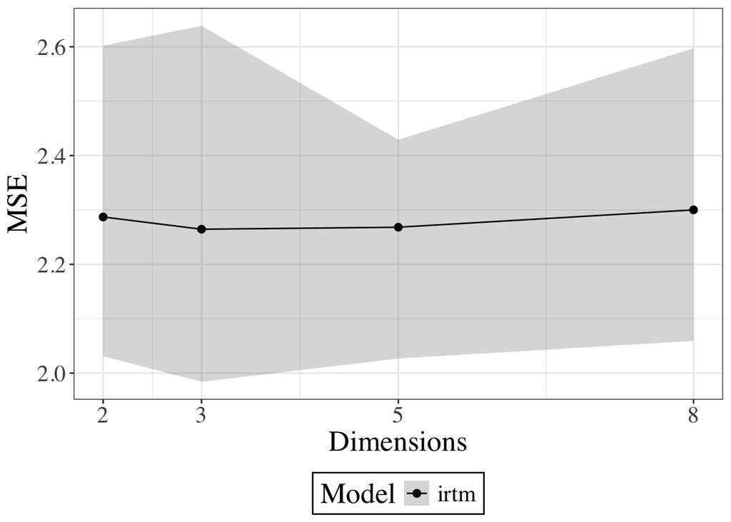

```
##
## > ## Time comparison
## >
## > p_time <- ggplot(time_results, aes(x= pass_d,
## +                                      y=avg,
## +                               .... [TRUNCATED]
##
## > p_time
```

```
##
## > ggsave(filename='simulations/results/figures/runtime_irtm_only.png',
## +        plot=p_time,
## +        dpi = 300,  width = 12, height=6)
```

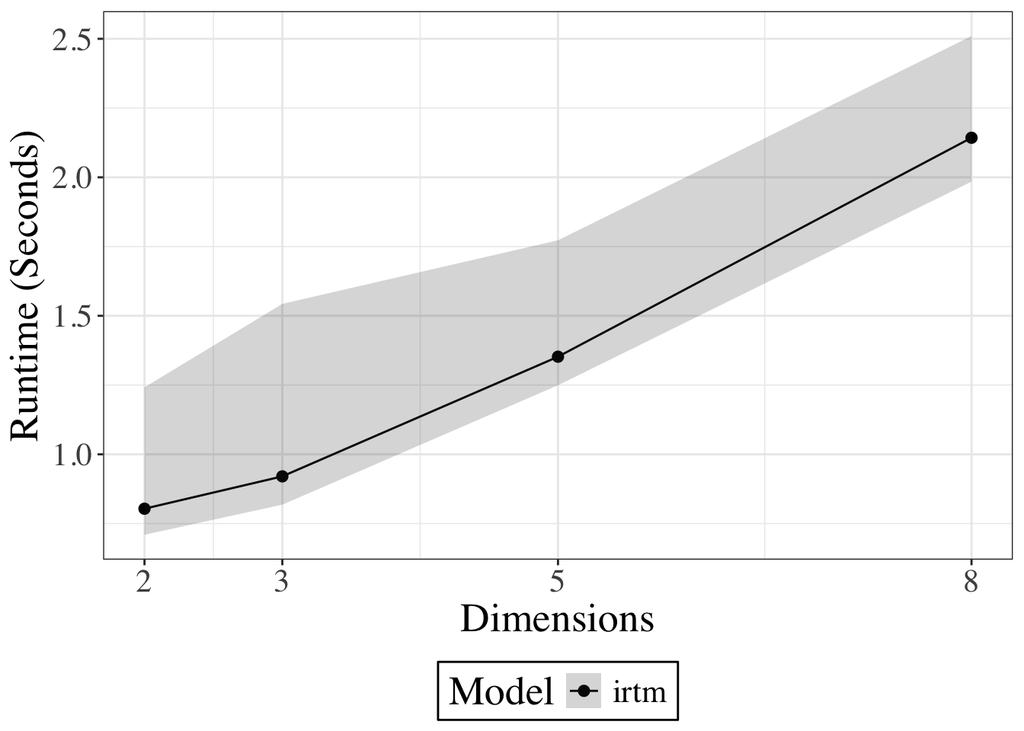

```
##
## > ## Percent failed models:
## > ## first count NA results by model and d specification
## >
## > ## Summarize the number of failed models
## > ## per dimension- .... [TRUNCATED]
## [1] 1
## [1] 2
## [1] 3
## [1] 4
## [1] 5
## [1] 6
## [1] 7
## [1] 8
## [1] 9
```

[output cut: 206 more lines]

```
##
## > ggsave(filename='simulations/results/figures/irtm_only_runtime_boxplot.png',
## +        plot=grtbox,
## +        dpi = 300,
## +        width = 12,
## +      .... [TRUNCATED]
```

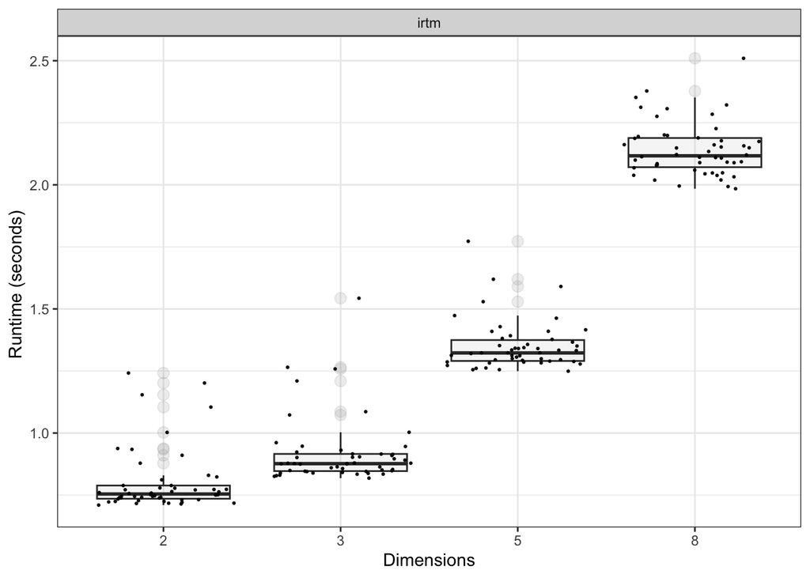

```r
source("code/irtm1_results_plots.R", echo = TRUE)
```

Simulation for effect of lambda sparsity 120 entries

```r
source("code/irtm_lambda_sparsity_sim.R", echo = TRUE)
```

```
##
## > ## This script analyzes effects of model sparsity on IRTM
## > ## N (100) and K (10) and d = 4, 6, 8
## > ## It does 50 iterations of each pair, with 50  .... [TRUNCATED]
##
## > library(mvtnorm)
##
## > library(coda)
##
## > library(nimble)
##
## > library(IRTM)
##
## > #library(blavaan)
## >
## > # Source custom helper functions
## > source('code/helpers.R') ## mse, custom plots
##
## > source('code/cfa_model_syntax.R') ## script to format CFA model input
##
## > source('code/format_cfa_lambda.R') ## script to format CFA loadings
##
## > source('code/blavPredict_format_conversion.R') #script to format blavaan samples
##
## > source('code/irtm_sims_gen_data.R') ## script to generate data
##
## > source('code/irtm_bsem_results_to_df.R') ## script to format list of results as single df
##
## > ## Data prep
## >
## > ### Declare params for sparsity analysis
## > ## Lambda zero percent:
## >
## > ## testing at: 25%, 50%, 75% sparsity
## > ## (need some spar .... [TRUNCATED]
##
## > K_vals = 10 # features
##
## > d_vals = c(2, 3, 5, 8)# dimensions
##
```

[output cut: 26 more lines]

```
## > ## marker to see which chain is running (if more than one)
## >
## > chain = 1
##
## > ## set up test subset:
## > ##120 rows:
## > small_sim <- sparsity_vals
##
## > for(i in 1:nrow(small_sim)){ ## open for loop
## +   print(paste0("Start pass ", i, ":"))
## +   pass_start <- Sys.time()
## +   params <- small_sim[i, c("Va ..." ... [TRUNCATED]
## [1] "Start pass 1:"
## [1] "round"
## [1] "Running IRT-M"
```

```
## Sampling...
```

```
## [1] "Start pass 2:"
## [1] "round"
## [1] "Running IRT-M"
```

```
## Sampling...
```

```
## [1] "Start pass 3:"
## [1] "round"
## [1] "Running IRT-M"
```

```
## Sampling...
```

```
## [1] "Start pass 4:"
## [1] "round"
## [1] "Running IRT-M"
```

```
## Sampling...
```

```
## [1] "Start pass 5:"
## [1] "round"
## [1] "Running IRT-M"
```

```
## Sampling...
```

```
## [1] "Start pass 6:"
## [1] "round"
## [1] "Running IRT-M"
```

```
## Sampling...
```

```
## [1] "Start pass 7:"
## [1] "round"
## [1] "Skipping this model; wrote dtails"
## [1] "Start pass 8:"
## [1] "round"
## [1] "Running IRT-M"
```

```
## Sampling...
```

```
## [1] "Start pass 9:"
## [1] "round"
## [1] "Running IRT-M"
```

```
## Sampling...
```

```
## [1] "Start pass 10:"
## [1] "round"
## [1] "Running IRT-M"
```

```
## Sampling...
```

```
## [1] "Start pass 11:"
## [1] "round"
## [1] "Running IRT-M"
```

```
## Sampling...
```

```
## [1] "Start pass 12:"
## [1] "round"
## [1] "Running IRT-M"
```

```
## Sampling...
```

```
## [1] "Start pass 13:"
## [1] "round"
## [1] "Running IRT-M"
```

```
## Sampling...
```

```
## [1] "Start pass 14:"
## [1] "round"
## [1] "Running IRT-M"
```

```
## Sampling...
```

```
## [1] "Start pass 15:"
## [1] "round"
## [1] "Running IRT-M"
```

```
## Sampling...
```

```
## [1] "Start pass 16:"
## [1] "round"
## [1] "Running IRT-M"
```

```
## Sampling...
```

```
## [1] "Start pass 17:"
## [1] "round"
## [1] "Running IRT-M"
```

```
## Sampling...
```

```
## [1] "Start pass 18:"
## [1] "round"
## [1] "Running IRT-M"
```

```
## Sampling...
```

```
## [1] "Start pass 19:"
## [1] "round"
## [1] "Running IRT-M"
```

```
## Sampling...
```

```
## [1] "Start pass 20:"
## [1] "round"
## [1] "Running IRT-M"
```

```
## Sampling...
```

```
## [1] "Start pass 21:"
## [1] "round"
## [1] "Running IRT-M"
```

```
## Sampling...
```

```
## [1] "Start pass 22:"
## [1] "round"
## [1] "Running IRT-M"
```

```
## Sampling...
```

```
## [1] "Start pass 23:"
## [1] "round"
## [1] "Running IRT-M"
```

```
## Sampling...
```

```
## [1] "Start pass 24:"
## [1] "round"
## [1] "Running IRT-M"
```

```
## Sampling...
```

```
## [1] "Start pass 25:"
## [1] "round"
## [1] "Running IRT-M"
```

```
## Sampling...
```

```
## [1] "Start pass 26:"
## [1] "round"
## [1] "Running IRT-M"
```

```
## Sampling...
```

```
## [1] "Start pass 27:"
## [1] "round"
## [1] "Skipping this model; wrote dtails"
## [1] "Start pass 28:"
## [1] "round"
## [1] "Running IRT-M"
```

```
## Sampling...
```

```
## [1] "Start pass 29:"
## [1] "round"
## [1] "Running IRT-M"
```

```
## Sampling...
```

```
## [1] "Start pass 30:"
## [1] "round"
## [1] "Running IRT-M"
```

```
## Sampling...
```

```
## [1] "Start pass 31:"
## [1] "round"
## [1] "Running IRT-M"
```

```
## Sampling...
```

```
## [1] "Start pass 32:"
## [1] "round"
## [1] "Running IRT-M"
```

```
## Sampling...
```

```
## [1] "Start pass 33:"
## [1] "round"
## [1] "Running IRT-M"
```

```
## Sampling...
```

```
## [1] "Start pass 34:"
## [1] "round"
## [1] "Running IRT-M"
```

```
## Sampling...
```

```
## [1] "Start pass 35:"
## [1] "round"
## [1] "Running IRT-M"
```

```
## Sampling...
```

```
## [1] "Start pass 36:"
## [1] "round"
## [1] "Running IRT-M"
```

```
## Sampling...
```

```
## [1] "Start pass 37:"
## [1] "round"
## [1] "Running IRT-M"
```

```
## Sampling...
```

```
## [1] "Start pass 38:"
## [1] "round"
## [1] "Running IRT-M"
```

```
## Sampling...
```

```
## [1] "Start pass 39:"
## [1] "round"
## [1] "Running IRT-M"
```

```
## Sampling...
```

```
## [1] "Start pass 40:"
## [1] "round"
## [1] "Running IRT-M"
```

```
## Sampling...
```

```
## [1] "Start pass 41:"
## [1] "round"
## [1] "Running IRT-M"
```

```
## Sampling...
```

```
## [1] "Start pass 42:"
## [1] "round"
## [1] "Running IRT-M"
```

```
## Sampling...
```

```
## [1] "Start pass 43:"
## [1] "round"
## [1] "Running IRT-M"
```

```
## Sampling...
```

```
## [1] "Start pass 44:"
## [1] "round"
## [1] "Running IRT-M"
```

```
## Sampling...
```

```
## [1] "Start pass 45:"
## [1] "round"
## [1] "Running IRT-M"
```

```
## Sampling...
```

```
## [1] "Start pass 46:"
## [1] "round"
## [1] "Running IRT-M"
```

```
## Sampling...
```

```
## [1] "Start pass 47:"
## [1] "round"
## [1] "Running IRT-M"
```

```
## Sampling...
```

```
## [1] "Start pass 48:"
## [1] "round"
## [1] "Running IRT-M"
```

```
## Sampling...
```

```
## [1] "Start pass 49:"
## [1] "round"
## [1] "Running IRT-M"
```

```
## Sampling...
```

```
## [1] "Start pass 50:"
## [1] "round"
## [1] "Running IRT-M"
```

```
## Sampling...
```

```
## [1] "Start pass 51:"
## [1] "round"
## [1] "Running IRT-M"
```

```
## Sampling...
```

```
## [1] "Start pass 52:"
## [1] "round"
## [1] "Running IRT-M"
```

```
## Sampling...
```

```
## [1] "Start pass 53:"
## [1] "round"
## [1] "Running IRT-M"
```

```
## Sampling...
```

```
## [1] "Start pass 54:"
## [1] "round"
## [1] "Running IRT-M"
```

```
## Sampling...
```

```
## [1] "Start pass 55:"
## [1] "round"
## [1] "Running IRT-M"
```

```
## Sampling...
```

```
## [1] "Start pass 56:"
## [1] "round"
## [1] "Running IRT-M"
```

```
## Sampling...
```

```
## [1] "Start pass 57:"
## [1] "round"
## [1] "Running IRT-M"
```

```
## Sampling...
```

```
## [1] "Start pass 58:"
## [1] "round"
## [1] "Running IRT-M"
```

```
## Sampling...
```

```
## [1] "Start pass 59:"
## [1] "round"
## [1] "Running IRT-M"
```

```
## Sampling...
```

```
## [1] "Start pass 60:"
## [1] "round"
## [1] "Running IRT-M"
```

```
## Sampling...
```

```
## [1] "Start pass 61:"
## [1] "round"
## [1] "Running IRT-M"
```

```
## Sampling...
```

```
## [1] "Start pass 62:"
## [1] "round"
## [1] "Running IRT-M"
```

```
## Sampling...
```

```
## [1] "Start pass 63:"
## [1] "round"
## [1] "Skipping this model; wrote dtails"
## [1] "Start pass 64:"
## [1] "round"
## [1] "Running IRT-M"
```

```
## Sampling...
```

```
## [1] "Start pass 65:"
## [1] "round"
## [1] "Running IRT-M"
```

```
## Sampling...
```

```
## [1] "Start pass 66:"
## [1] "round"
## [1] "Running IRT-M"
```

```
## Sampling...
```

```
## [1] "Start pass 67:"
## [1] "round"
## [1] "Running IRT-M"
```

```
## Sampling...
```

```
## [1] "Start pass 68:"
## [1] "round"
## [1] "Running IRT-M"
```

```
## Sampling...
```

```
## [1] "Start pass 69:"
## [1] "round"
## [1] "Running IRT-M"
```

```
## Sampling...
```

```
## [1] "Start pass 70:"
## [1] "round"
## [1] "Running IRT-M"
```

```
## Sampling...
```

```
## [1] "Start pass 71:"
## [1] "round"
## [1] "Running IRT-M"
```

```
## Sampling...
```

```
## [1] "Start pass 72:"
## [1] "round"
## [1] "Running IRT-M"
```

```
## Sampling...
```

```
## [1] "Start pass 73:"
## [1] "round"
## [1] "Running IRT-M"
```

```
## Sampling...
```

```
## [1] "Start pass 74:"
## [1] "round"
## [1] "Running IRT-M"
```

```
## Sampling...
```

```
## [1] "Start pass 75:"
## [1] "round"
## [1] "Running IRT-M"
```

```
## Sampling...
```

```
## [1] "Start pass 76:"
## [1] "round"
## [1] "Running IRT-M"
```

```
## Sampling...
```

```
## [1] "Start pass 77:"
## [1] "round"
## [1] "Running IRT-M"
```

```
## Sampling...
```

```
## [1] "Start pass 78:"
## [1] "round"
## [1] "Running IRT-M"
```

```
## Sampling...
```

```
## [1] "Start pass 79:"
## [1] "round"
## [1] "Running IRT-M"
```

```
## Sampling...
```

```
## [1] "Start pass 80:"
## [1] "round"
## [1] "Running IRT-M"
```

```
## Sampling...
```

```
## [1] "Start pass 81:"
## [1] "round"
## [1] "Running IRT-M"
```

```
## Sampling...
```

```
## [1] "Start pass 82:"
## [1] "round"
## [1] "Running IRT-M"
```

```
## Sampling...
```

```
## [1] "Start pass 83:"
## [1] "round"
## [1] "Running IRT-M"
```

```
## Sampling...
```

```
## [1] "Start pass 84:"
## [1] "round"
## [1] "Running IRT-M"
```

```
## Sampling...
```

```
## [1] "Start pass 85:"
## [1] "round"
## [1] "Running IRT-M"
```

```
## Sampling...
```

```
## [1] "Start pass 86:"
## [1] "round"
## [1] "Running IRT-M"
```

```
## Sampling...
```

```
## [1] "Start pass 87:"
## [1] "round"
## [1] "Running IRT-M"
```

```
## Sampling...
```

```
## [1] "Start pass 88:"
## [1] "round"
## [1] "Skipping this model; wrote dtails"
## [1] "Start pass 89:"
## [1] "round"
## [1] "Running IRT-M"
```

```
## Sampling...
```

```
## [1] "Start pass 90:"
## [1] "round"
## [1] "Running IRT-M"
```

```
## Sampling...
```

```
## [1] "Start pass 91:"
## [1] "round"
## [1] "Running IRT-M"
```

```
## Sampling...
```

```
## [1] "Start pass 92:"
## [1] "round"
## [1] "Running IRT-M"
```

```
## Sampling...
```

```
## [1] "Start pass 93:"
## [1] "round"
## [1] "Running IRT-M"
```

```
## Sampling...
```

```
## [1] "Start pass 94:"
## [1] "round"
## [1] "Running IRT-M"
```

```
## Sampling...
```

```
## [1] "Start pass 95:"
## [1] "round"
## [1] "Running IRT-M"
```

```
## Sampling...
```

```
## [1] "Start pass 96:"
## [1] "round"
## [1] "Running IRT-M"
```

```
## Sampling...
```

```
## [1] "Start pass 97:"
## [1] "round"
## [1] "Running IRT-M"
```

```
## Sampling...
```

```
## [1] "Start pass 98:"
## [1] "round"
## [1] "Running IRT-M"
```

```
## Sampling...
```

```
## [1] "Start pass 99:"
## [1] "round"
## [1] "Running IRT-M"
```

```
## Sampling...
```

```
## [1] "Start pass 100:"
## [1] "round"
## [1] "Running IRT-M"
```

```
## Sampling...
```

```
## [1] "Start pass 101:"
## [1] "round"
## [1] "Running IRT-M"
```

```
## Sampling...
```

```
## [1] "Start pass 102:"
## [1] "round"
## [1] "Running IRT-M"
```

```
## Sampling...
```

```
## [1] "Start pass 103:"
## [1] "round"
## [1] "Running IRT-M"
```

```
## Sampling...
```

```
## [1] "Start pass 104:"
## [1] "round"
## [1] "Running IRT-M"
```

```
## Sampling...
```

```
## [1] "Start pass 105:"
## [1] "round"
## [1] "Running IRT-M"
```

```
## Sampling...
```

```
## [1] "Start pass 106:"
## [1] "round"
## [1] "Running IRT-M"
```

```
## Sampling...
```

```
## [1] "Start pass 107:"
## [1] "round"
## [1] "Running IRT-M"
```

```
## Sampling...
```

```
## [1] "Start pass 108:"
## [1] "round"
## [1] "Running IRT-M"
```

```
## Sampling...
```

```
## [1] "Start pass 109:"
## [1] "round"
## [1] "Running IRT-M"
```

```
## Sampling...
```

```
## [1] "Start pass 110:"
## [1] "round"
## [1] "Running IRT-M"
```

```
## Sampling...
```

```
## [1] "Start pass 111:"
## [1] "round"
## [1] "Skipping this model; wrote dtails"
## [1] "Start pass 112:"
## [1] "round"
## [1] "Running IRT-M"
```

```
## Sampling...
```

```
## [1] "Start pass 113:"
## [1] "round"
## [1] "Running IRT-M"
```

```
## Sampling...
```

```
## [1] "Start pass 114:"
## [1] "round"
## [1] "Running IRT-M"
```

```
## Sampling...
```

```
## [1] "Start pass 115:"
## [1] "round"
## [1] "Running IRT-M"
```

```
## Sampling...
```

```
## [1] "Start pass 116:"
## [1] "round"
## [1] "Running IRT-M"
```

```
## Sampling...
```

```
## [1] "Start pass 117:"
## [1] "round"
## [1] "Running IRT-M"
```

```
## Sampling...
```

```
## [1] "Start pass 118:"
## [1] "round"
## [1] "Skipping this model; wrote dtails"
## [1] "Start pass 119:"
## [1] "round"
## [1] "Running IRT-M"
```

```
## Sampling...
```

```
## [1] "Start pass 120:"
## [1] "round"
## [1] "Running IRT-M"
```

```
## Sampling...
```

```
##
## > ## Save results
## > fname = paste0("simulations/irtm_only_lambda_sparsity.rds")
##
## > save(all_results, file=fname)
##
## > ## save time info
## > tname = paste0("simulations/irtm_only_lambda_sparsity_time.rds")
##
## > save(model_times, file=tname)
##
## > ### save param data for analysis:
## > sname = paste0("simulations/irtm_small_sim_params_sparsity.rds")
##
## > save(small_sim, file=sname)
```

produces: irtm_only_lambda_sparsity_time.rds irtm_only_lambda_sparsity.rds irtm_small_sim_params_sparsity.rds ## parameters

```
##
## > ## Results:
## > ## takes dataframe of results
## > ## produces graphs
## >
## > library(dplyr)
##
## > library(tidyr)
##
## > library(ggplot2)
##
## > source('code/irtm_only_results_to_df_lambds.R') ## script to format list of results as single df
##
## > source('code/na_indicies.R') # helper to find NA values in model comparisons
##
## > ## Load data:
## >
## > ## params:
## > load("simulations/irtm_small_sim_params_sparsity.rds")
##
## > ## all_results:
## > load("simulations/irtm_only_lambda_sparsity.rds")
##
## > ## model_times:
## > load("simulations/irtm_only_lambda_sparsity_time.rds")
##
## > ## %%%%%%%%%%%%% Data Prep
## > ## Standardize list names for the time list:
## >
## > all_results <- lapply(all_results, function(x) {
## +   if ("irtM" %in%  .... [TRUNCATED]
##
## > all_results <- lapply(all_results, function(x) {
## +   if ("CFA" %in% names(x)) {
## +     names(x)[names(x) == "CFA"] <- "bcfa"
## +   }
## +   return(x)
## + })
##
## > ## get index of NA values in the sim results
```

[output cut: 472 more lines]

```
## NULL
## [1] "passed case 1"
## [1] 117
## [1] "i = 117 names: irtm"
## NULL
## [1] "passed case 1"
## [1] 118
## [1] 119
## [1] "i = 119 names: irtm"
## NULL
## [1] "passed case 1"
## [1] 120
## [1] "i = 120 names: irtm"
## NULL
## [1] "passed case 1"
```

```
##
## > sim_results$statistic <- "MSE" # for tracking
##
## > ## Data for Fig 2: Runtime by model
## > time_results <- irtm_results_to_df2(updated_time,
## +                                    small_sim,
## +            .... [TRUNCATED]
## [1] 1
## [1] "i = 1 names: irtm"
## NULL
## [1] "passed case 1"
## [1] 2
## [1] "i = 2 names: irtm"
## NULL
## [1] "passed case 1"
```

[output cut: 454 more lines]

```
##
## > time_results$statistic <- "runtime"
##
## > ## Data for Fig 3:  count NA by models:
## >
## > na_count_by_group <- irtm_results_to_df2(standardized_mse_results,
## +                                    .... [TRUNCATED]
## [1] 1
## [1] "i = 1 names: irtm"
## NULL
## [1] "passed case 1"
## [1] 2
## [1] "i = 2 names: irtm"
## NULL
## [1] "passed case 1"
```

[output cut: 454 more lines]

```
##
## > ##%%%%%%%%%%%%%%%%%%%%
## > ## Plots:
## >
## > p_results <- ggplot(sim_results, aes(x= pass_d,
## +                                      y=avg,
## +             .... [TRUNCATED]
##
## > p_results
```

```
##
## > ggsave(filename='simulations/results/figures/irt-only_sparsity.png',
## +        plot=p_results,
## +        dpi = 300,  width = 12, height=6)
```

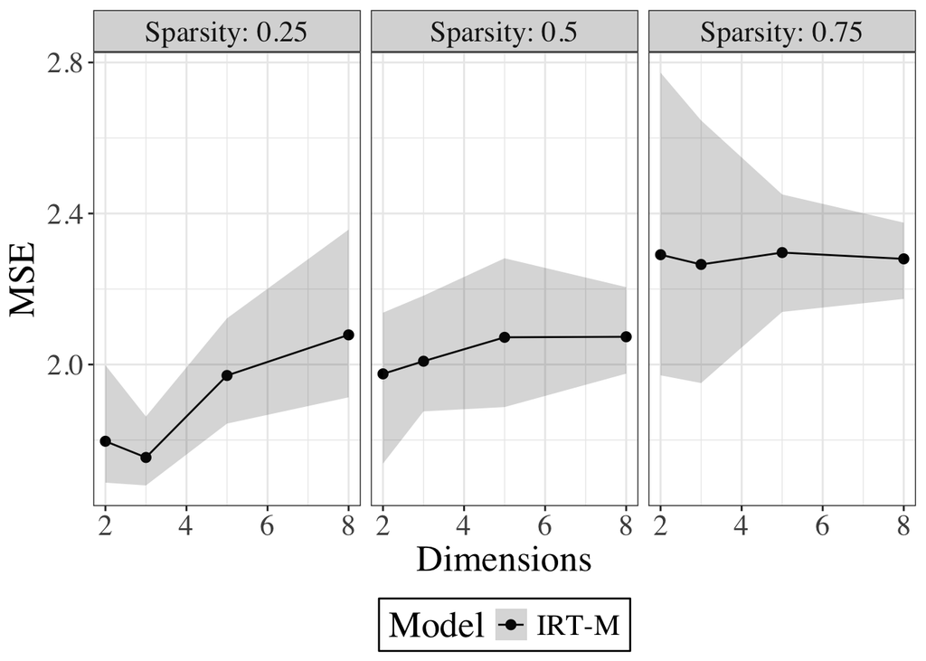

```
##
## > ## Time comparison
## >
## > ## the long bcfa and bsem times overwhelm variation in IRTM times:
## >
## > ## Might wnat to make this into a table:
## > ## number .... [TRUNCATED]
## # A tibble: 12 × 7
## # Groups:   pass_d [4]
##    pass_d Sparsity model   avg   min   max statistic
##     <dbl>    <dbl> <chr> <dbl> <dbl> <dbl> <chr>
##  1      2     0.25 IRT-M 0.790 0.712 0.982 runtime
##  2      2     0.5  IRT-M 0.792 0.707 1.10  runtime
##  3      2     0.75 IRT-M 0.745 0.688 0.798 runtime
##  4      3     0.25 IRT-M 0.897 0.827 1.09  runtime
##  5      3     0.5  IRT-M 0.868 0.823 0.958 runtime
##  6      3     0.75 IRT-M 0.895 0.826 1.06  runtime
##  7      5     0.25 IRT-M 1.38  1.28  1.53  runtime
##  8      5     0.5  IRT-M 1.34  1.29  1.45  runtime
##  9      5     0.75 IRT-M 1.41  1.29  1.68  runtime
## 10      8     0.25 IRT-M 2.17  2.04  2.57  runtime
## 11      8     0.5  IRT-M 2.15  2.05  2.29  runtime
## 12      8     0.75 IRT-M 2.17  2.05  2.47  runtime
##
## > p_time <- ggplot(time_results, aes(x= pass_d,
## +                                    y=avg,
## +                                    ymin=min,
## +         .... [TRUNCATED]
##
## > p_time
```

```
##
## > ggsave(filename='simulations/results/figures/runtime_irt-only_lambda_sparse.png',
## +        plot=p_time,
## +        dpi = 300,  width = 12, height=6)
```

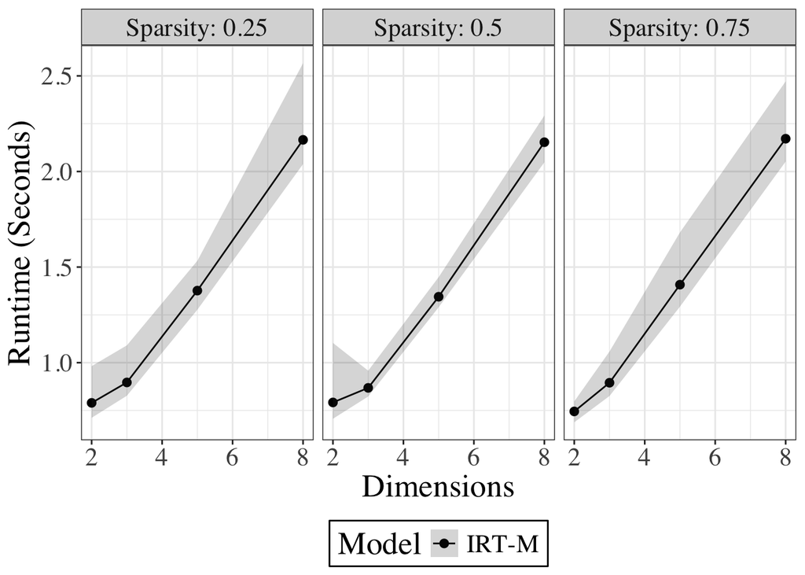

```
##
## > ## Percent failed models:
## > ## first count NA results by model and d specification
## >
## > ## Summarize the number of failed models
## > ## per dimension- .... [TRUNCATED]
##
## > ggmiss
```

```
##
## > ggsave(filename='simulations/results/figures/irtm-only_failed_models_lambda.png',
## +        plot=ggmiss,
## +        dpi = 300,
## +        width = 12,
## + .... [TRUNCATED]
```

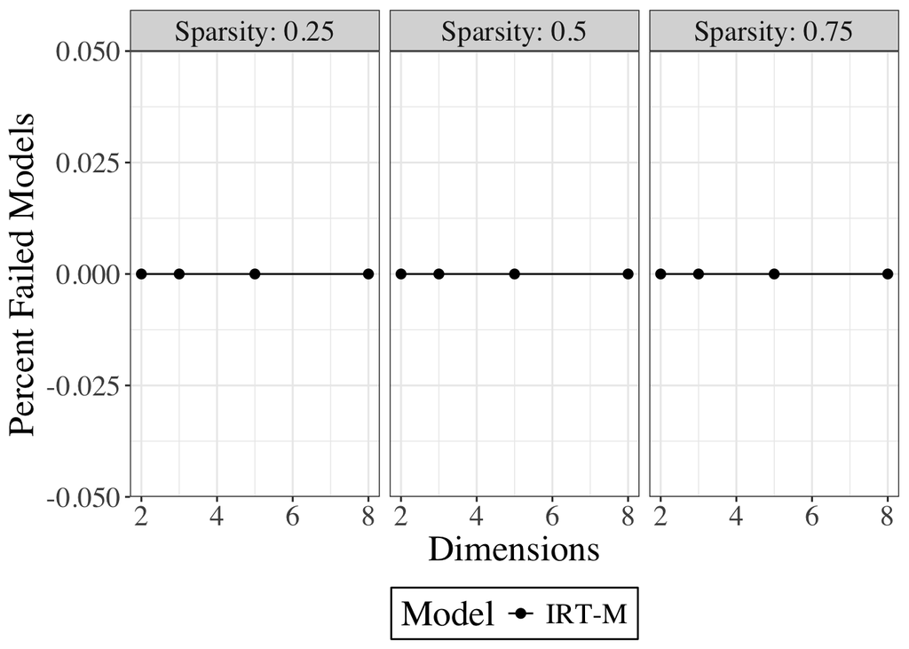

```r
##
## Lambda sparsity figures:
source("code/irtm_only_lamba_sparsity_plots.R", echo = TRUE)
```

```r
##%%%%%%%%%%%%%%%%%%%
## Benchmark time for a wider range of parameters:
##%%%%%%%%%%%%%%%%%%%%%%
```

Simulation runs N, K range for 10 passes each. 480 entries, less cases where d > k Only IRT=M:

```r
source("code/irtm_only_single_pass_for_time.R", echo = TRUE)
```

```
##
## > ## This is a single pass through to get an approximate
## > ## time benchmark for IRTM vs other models
## >
## > library(MASS)
##
## > library(mvtnorm)
##
## > library(coda)
##
## > library(nimble)
##
## > library(IRTM)
##
## > library(dplyr)
##
## > # Source custom helper functions
## > source('code/helpers.R') ## mse, custom plots
##
## > source('code/cfa_model_syntax.R') ## script to format CFA model input
##
## > source('code/format_cfa_lambda.R') ## script to format CFA loadings
##
## > source('code/blavPredict_format_conversion.R') #script to format blavaan samples
##
## > source('code/irtm_sims_gen_data.R') ## script to generate data
##
## > source('code/irtm_bsem_results_to_df.R') ## script to format list of results as single df
##
## > ## Make names to save partial `results:
## > ##
## >
## > tpartname = "simulations/irtm_only_time_partial_.rds"
##
## > ppartname = "simulations/irtm_only_params_partial_.rds"
##
## > rpartname = "simulations/irtm_only_res_partial_.rds"
##
## > ## Data prep
## >
```

[output cut: 90 more lines]

```
## [1] "round"
## [1] "Model incompatible with sem/cfa; wrote dtails"
## [1] "Start pass 10:"
## [1] "Start time: 2025-08-08 21:28:11.283334"
## [1] "round"
## [1] "Model incompatible with sem/cfa; wrote dtails"
## [1] "Start pass 11:"
## [1] "Start time: 2025-08-08 21:28:11.844231"
## [1] "round"
## [1] "Model incompatible with sem/cfa; wrote dtails"
## [1] "Start pass 12:"
## [1] "Start time: 2025-08-08 21:28:11.851016"
## [1] "round"
## [1] "Running IRT-M"
## [1] "IRT-M start time: 2025-08-08 21:28:11.856309"
```

```
## Sampling...
```

```
## [1] "IRT-M End time: 2025-08-08 21:28:12.20582"
## [1] "run_time: 0.34951114654541"
## [1] "End time: 2025-08-08 21:28:12.315203"
## [1] "Pass took 0.4642"
## [1] "Start pass 13:"
## [1] "Start time: 2025-08-08 21:28:12.315587"
## [1] "round"
## [1] "Running IRT-M"
## [1] "IRT-M start time: 2025-08-08 21:28:12.322114"
```

```
## Sampling...
```

```
## [1] "IRT-M End time: 2025-08-08 21:28:12.662996"
## [1] "run_time: 0.340882062911987"
## [1] "End time: 2025-08-08 21:28:12.75875"
## [1] "Pass took 0.4432"
## [1] "Start pass 14:"
## [1] "Start time: 2025-08-08 21:28:12.759143"
## [1] "round"
## [1] "Model incompatible with sem/cfa; wrote dtails"
## [1] "Start pass 15:"
## [1] "Start time: 2025-08-08 21:28:12.768217"
## [1] "round"
## [1] "Model incompatible with sem/cfa; wrote dtails"
## [1] "Start pass 16:"
## [1] "Start time: 2025-08-08 21:28:12.781289"
## [1] "round"
## [1] "Running IRT-M"
## [1] "IRT-M start time: 2025-08-08 21:28:12.787596"
```

```
## Sampling...
```

```
## [1] "IRT-M End time: 2025-08-08 21:28:13.099707"
## [1] "run_time: 0.312110900878906"
## [1] "End time: 2025-08-08 21:28:13.152854"
## [1] "Pass took 0.3716"
## [1] "Start pass 17:"
## [1] "Start time: 2025-08-08 21:28:13.153277"
## [1] "round"
## [1] "Model incompatible with sem/cfa; wrote dtails"
## [1] "Start pass 18:"
## [1] "Start time: 2025-08-08 21:28:13.160798"
## [1] "round"
## [1] "Model incompatible with sem/cfa; wrote dtails"
## [1] "Start pass 19:"
## [1] "Start time: 2025-08-08 21:28:13.169266"
## [1] "round"
## [1] "Model incompatible with sem/cfa; wrote dtails"
## [1] "Start pass 20:"
## [1] "Start time: 2025-08-08 21:28:13.176125"
## [1] "round"
## [1] "Running IRT-M"
## [1] "IRT-M start time: 2025-08-08 21:28:13.181846"
```

```
## Sampling...
```

```
## [1] "IRT-M End time: 2025-08-08 21:28:13.652027"
## [1] "run_time: 0.470180988311768"
## [1] "End time: 2025-08-08 21:28:13.711207"
## [1] "Pass took 0.5351"
## [1] "Start pass 21:"
## [1] "Start time: 2025-08-08 21:28:13.713384"
## [1] "round"
## [1] "Model incompatible with sem/cfa; wrote dtails"
## [1] "Start pass 22:"
## [1] "Start time: 2025-08-08 21:28:13.725072"
## [1] "round"
## [1] "Model incompatible with sem/cfa; wrote dtails"
## [1] "Start pass 23:"
## [1] "Start time: 2025-08-08 21:28:13.733476"
## [1] "round"
## [1] "Model incompatible with sem/cfa; wrote dtails"
## [1] "Start pass 24:"
## [1] "Start time: 2025-08-08 21:28:13.741465"
## [1] "round"
## [1] "Model incompatible with sem/cfa; wrote dtails"
## [1] "Start pass 25:"
## [1] "Start time: 2025-08-08 21:28:13.749708"
## [1] "round"
## [1] "Running IRT-M"
## [1] "IRT-M start time: 2025-08-08 21:28:13.756196"
```

```
## Sampling...
```

```
## [1] "IRT-M End time: 2025-08-08 21:28:14.920429"
## [1] "run_time: 1.16423296928406"
## [1] "End time: 2025-08-08 21:28:15.113063"
## [1] "Pass took 1.3634"
## [1] "Start pass 26:"
## [1] "Start time: 2025-08-08 21:28:15.115113"
## [1] "round"
## [1] "Model incompatible with sem/cfa; wrote dtails"
## [1] "Start pass 27:"
## [1] "Start time: 2025-08-08 21:28:15.12446"
## [1] "round"
## [1] "Model incompatible with sem/cfa; wrote dtails"
## [1] "Start pass 28:"
## [1] "Start time: 2025-08-08 21:28:15.131469"
## [1] "round"
## [1] "Model incompatible with sem/cfa; wrote dtails"
## [1] "Start pass 29:"
## [1] "Start time: 2025-08-08 21:28:15.138587"
## [1] "round"
## [1] "Running IRT-M"
## [1] "IRT-M start time: 2025-08-08 21:28:15.146475"
```

```
## Sampling...
```

```
## [1] "IRT-M End time: 2025-08-08 21:28:16.475819"
## [1] "run_time: 1.32934403419495"
## [1] "End time: 2025-08-08 21:28:16.691042"
## [1] "Pass took 1.5525"
## [1] "Start pass 30:"
## [1] "Start time: 2025-08-08 21:28:16.69163"
## [1] "round"
## [1] "Model incompatible with sem/cfa; wrote dtails"
## [1] "Start pass 31:"
## [1] "Start time: 2025-08-08 21:28:16.70617"
## [1] "round"
## [1] "Running IRT-M"
## [1] "IRT-M start time: 2025-08-08 21:28:16.792488"
```

```
## Sampling...
```

```
## [1] "IRT-M End time: 2025-08-08 21:28:20.226912"
## [1] "run_time: 3.43442392349243"
## [1] "End time: 2025-08-08 21:28:20.455487"
## [1] "Pass took 3.7493"
## [1] "Start pass 32:"
## [1] "Start time: 2025-08-08 21:28:20.455979"
## [1] "round"
## [1] "Running IRT-M"
## [1] "IRT-M start time: 2025-08-08 21:28:20.529228"
```

```
## Sampling...
```

```
## [1] "IRT-M End time: 2025-08-08 21:28:23.850423"
## [1] "run_time: 3.32119512557983"
## [1] "End time: 2025-08-08 21:28:24.100054"
## [1] "Pass took 3.6441"
## [1] "Start pass 33:"
## [1] "Start time: 2025-08-08 21:28:24.100614"
## [1] "round"
## [1] "Running IRT-M"
## [1] "IRT-M start time: 2025-08-08 21:28:24.167973"
```

```
## Sampling...
```

```
## [1] "IRT-M End time: 2025-08-08 21:28:27.522527"
## [1] "run_time: 3.35455393791199"
## [1] "End time: 2025-08-08 21:28:27.710917"
## [1] "Pass took 3.6103"
## [1] "Start pass 34:"
## [1] "Start time: 2025-08-08 21:28:27.711301"
## [1] "round"
## [1] "Running IRT-M"
## [1] "IRT-M start time: 2025-08-08 21:28:27.764739"
```

```
## Sampling...
```

```
## [1] "IRT-M End time: 2025-08-08 21:28:31.432264"
## [1] "run_time: 3.66752505302429"
## [1] "End time: 2025-08-08 21:28:31.689547"
## [1] "Pass took 3.9782"
## [1] "Start pass 35:"
## [1] "Start time: 2025-08-08 21:28:31.689956"
## [1] "round"
## [1] "Running IRT-M"
## [1] "IRT-M start time: 2025-08-08 21:28:31.860979"
```

```
## Sampling...
```

```
## [1] "IRT-M End time: 2025-08-08 21:28:37.938652"
## [1] "run_time: 6.07767295837402"
## [1] "End time: 2025-08-08 21:28:38.165171"
## [1] "Pass took 6.4752"
## [1] "Start pass 36:"
## [1] "Start time: 2025-08-08 21:28:38.167652"
## [1] "round"
## [1] "Running IRT-M"
## [1] "IRT-M start time: 2025-08-08 21:28:38.231649"
```

```
## Sampling...
```

```
## [1] "IRT-M End time: 2025-08-08 21:28:42.755024"
## [1] "run_time: 4.52337503433228"
## [1] "End time: 2025-08-08 21:28:42.999717"
## [1] "Pass took 4.8321"
## [1] "Start pass 37:"
## [1] "Start time: 2025-08-08 21:28:43.000168"
## [1] "round"
## [1] "Running IRT-M"
## [1] "IRT-M start time: 2025-08-08 21:28:43.081585"
```

```
## Sampling...
```

```
## [1] "IRT-M End time: 2025-08-08 21:28:46.538034"
## [1] "run_time: 3.45644903182983"
## [1] "End time: 2025-08-08 21:28:46.763598"
## [1] "Pass took 3.7634"
## [1] "Start pass 38:"
## [1] "Start time: 2025-08-08 21:28:46.764015"
## [1] "round"
## [1] "Running IRT-M"
## [1] "IRT-M start time: 2025-08-08 21:28:46.843689"
```

```
## Sampling...
```

```
## [1] "IRT-M End time: 2025-08-08 21:28:50.047763"
## [1] "run_time: 3.2040741443634"
## [1] "End time: 2025-08-08 21:28:50.254614"
## [1] "Pass took 3.4906"
## [1] "Start pass 39:"
## [1] "Start time: 2025-08-08 21:28:50.255019"
## [1] "round"
## [1] "Running IRT-M"
## [1] "IRT-M start time: 2025-08-08 21:28:50.31001"
```

```
## Sampling...
```

```
## [1] "IRT-M End time: 2025-08-08 21:28:53.493145"
## [1] "run_time: 3.18313503265381"
## [1] "End time: 2025-08-08 21:28:53.704645"
## [1] "Pass took 3.4496"
## [1] "Start pass 40:"
## [1] "Start time: 2025-08-08 21:28:53.705115"
## [1] "round"
## [1] "Running IRT-M"
## [1] "IRT-M start time: 2025-08-08 21:28:53.761852"
```

```
## Sampling...
```

```
## [1] "IRT-M End time: 2025-08-08 21:28:56.892291"
## [1] "run_time: 3.13043904304504"
## [1] "End time: 2025-08-08 21:28:57.108043"
## [1] "Pass took 3.4029"
## [1] "Start pass 41:"
## [1] "Start time: 2025-08-08 21:28:57.109777"
## [1] "round"
## [1] "Running IRT-M"
## [1] "IRT-M start time: 2025-08-08 21:28:57.324726"
```

```
## Sampling...
```

```
## [1] "IRT-M End time: 2025-08-08 21:29:08.140968"
## [1] "run_time: 10.816241979599"
## [1] "End time: 2025-08-08 21:29:08.716791"
## [1] "Pass took 11.607"
## [1] "Start pass 42:"
## [1] "Start time: 2025-08-08 21:29:08.717331"
## [1] "round"
## [1] "Running IRT-M"
## [1] "IRT-M start time: 2025-08-08 21:29:08.970968"
```

```
## Sampling...
```

```
## [1] "IRT-M End time: 2025-08-08 21:29:19.810743"
## [1] "run_time: 10.8397750854492"
## [1] "End time: 2025-08-08 21:29:20.332615"
## [1] "Pass took 11.6153"
## [1] "Start pass 43:"
## [1] "Start time: 2025-08-08 21:29:20.333008"
## [1] "round"
## [1] "Running IRT-M"
## [1] "IRT-M start time: 2025-08-08 21:29:20.574236"
```

```
## Sampling...
```

```
## [1] "IRT-M End time: 2025-08-08 21:29:31.17921"
## [1] "run_time: 10.6049740314484"
## [1] "End time: 2025-08-08 21:29:31.695606"
## [1] "Pass took 11.3626"
## [1] "Start pass 44:"
## [1] "Start time: 2025-08-08 21:29:31.696093"
## [1] "round"
## [1] "Running IRT-M"
## [1] "IRT-M start time: 2025-08-08 21:29:31.913217"
```

```
## Sampling...
```

```
## [1] "IRT-M End time: 2025-08-08 21:29:42.631504"
## [1] "run_time: 10.7182869911194"
## [1] "End time: 2025-08-08 21:29:43.146818"
## [1] "Pass took 11.4507"
## [1] "Start pass 45:"
## [1] "Start time: 2025-08-08 21:29:43.147193"
## [1] "round"
## [1] "Running IRT-M"
## [1] "IRT-M start time: 2025-08-08 21:29:43.334455"
```

```
## Sampling...
```

```
## [1] "IRT-M End time: 2025-08-08 21:29:54.198637"
## [1] "run_time: 10.8641819953918"
## [1] "End time: 2025-08-08 21:29:54.708323"
## [1] "Pass took 11.5611"
## [1] "Start pass 46:"
## [1] "Start time: 2025-08-08 21:29:54.711978"
## [1] "round"
## [1] "Running IRT-M"
## [1] "IRT-M start time: 2025-08-08 21:29:54.902071"
```

```
## Sampling...
```

```
## [1] "IRT-M End time: 2025-08-08 21:30:05.615683"
## [1] "run_time: 10.7136120796204"
## [1] "End time: 2025-08-08 21:30:06.216409"
## [1] "Pass took 11.5044"
## [1] "Start pass 47:"
## [1] "Start time: 2025-08-08 21:30:06.217021"
## [1] "round"
## [1] "Running IRT-M"
## [1] "IRT-M start time: 2025-08-08 21:30:06.42969"
```

```
## Sampling...
```

```
## [1] "IRT-M End time: 2025-08-08 21:30:17.285187"
## [1] "run_time: 10.8554971218109"
## [1] "End time: 2025-08-08 21:30:17.816927"
## [1] "Pass took 11.5999"
## [1] "Start pass 48:"
## [1] "Start time: 2025-08-08 21:30:17.8173"
## [1] "round"
## [1] "Running IRT-M"
## [1] "IRT-M start time: 2025-08-08 21:30:17.997536"
```

```
## Sampling...
```

```
## [1] "IRT-M End time: 2025-08-08 21:30:28.562617"
## [1] "run_time: 10.5650811195374"
## [1] "End time: 2025-08-08 21:30:29.090401"
## [1] "Pass took 11.2731"
## [1] "Start pass 49:"
## [1] "Start time: 2025-08-08 21:30:29.090863"
## [1] "round"
## [1] "Running IRT-M"
## [1] "IRT-M start time: 2025-08-08 21:30:29.287119"
```

```
## Sampling...
```

```
## [1] "IRT-M End time: 2025-08-08 21:30:39.686738"
## [1] "run_time: 10.399619102478"
## [1] "End time: 2025-08-08 21:30:40.218184"
## [1] "Pass took 11.1273"
## [1] "Start pass 50:"
## [1] "Start time: 2025-08-08 21:30:40.218558"
## [1] "round"
## [1] "Running IRT-M"
## [1] "IRT-M start time: 2025-08-08 21:30:40.397675"
```

```
## Sampling...
```

```
## [1] "IRT-M End time: 2025-08-08 21:30:51.957598"
## [1] "run_time: 11.5599229335785"
## [1] "End time: 2025-08-08 21:30:52.500803"
## [1] "Pass took 12.2822"
## [1] "Start pass 51:"
## [1] "Start time: 2025-08-08 21:30:52.50491"
## [1] "round"
## [1] "Running IRT-M"
## [1] "IRT-M start time: 2025-08-08 21:30:52.659884"
```

```
## Sampling...
```

```
## [1] "IRT-M End time: 2025-08-08 21:31:05.503953"
## [1] "run_time: 12.8440690040588"
## [1] "End time: 2025-08-08 21:31:06.142316"
## [1] "Pass took 13.6374"
## [1] "Start pass 52:"
## [1] "Start time: 2025-08-08 21:31:06.142725"
## [1] "round"
## [1] "Running IRT-M"
## [1] "IRT-M start time: 2025-08-08 21:31:06.259079"
```

```
## Sampling...
```

```
## [1] "IRT-M End time: 2025-08-08 21:31:18.79916"
## [1] "run_time: 12.5400810241699"
## [1] "End time: 2025-08-08 21:31:19.418209"
## [1] "Pass took 13.2755"
## [1] "Start pass 53:"
## [1] "Start time: 2025-08-08 21:31:19.418615"
## [1] "round"
## [1] "Running IRT-M"
## [1] "IRT-M start time: 2025-08-08 21:31:19.535421"
```

```
## Sampling...
```

```
## [1] "IRT-M End time: 2025-08-08 21:31:31.9816"
## [1] "run_time: 12.446179151535"
## [1] "End time: 2025-08-08 21:31:33.015123"
## [1] "Pass took 13.5965"
## [1] "Start pass 54:"
## [1] "Start time: 2025-08-08 21:31:33.015644"
## [1] "round"
## [1] "Running IRT-M"
## [1] "IRT-M start time: 2025-08-08 21:31:33.150153"
```

```
## Sampling...
```

```
## [1] "IRT-M End time: 2025-08-08 21:31:45.738455"
## [1] "run_time: 12.5883021354675"
## [1] "End time: 2025-08-08 21:31:46.325176"
## [1] "Pass took 13.3095"
## [1] "Start pass 55:"
## [1] "Start time: 2025-08-08 21:31:46.325534"
## [1] "round"
## [1] "Running IRT-M"
## [1] "IRT-M start time: 2025-08-08 21:31:46.44773"
```

```
## Sampling...
```

```
## [1] "IRT-M End time: 2025-08-08 21:31:58.843442"
## [1] "run_time: 12.3957118988037"
## [1] "End time: 2025-08-08 21:31:59.438331"
## [1] "Pass took 13.1128"
## [1] "Start pass 56:"
## [1] "Start time: 2025-08-08 21:31:59.442114"
## [1] "round"
## [1] "Running IRT-M"
## [1] "IRT-M start time: 2025-08-08 21:31:59.563707"
```

```
## Sampling...
```

```
## [1] "IRT-M End time: 2025-08-08 21:32:12.447119"
## [1] "run_time: 12.8834118843079"
## [1] "End time: 2025-08-08 21:32:13.128406"
## [1] "Pass took 13.6863"
## [1] "Start pass 57:"
## [1] "Start time: 2025-08-08 21:32:13.128963"
## [1] "round"
## [1] "Running IRT-M"
## [1] "IRT-M start time: 2025-08-08 21:32:13.271222"
```

```
## Sampling...
```

```
## [1] "IRT-M End time: 2025-08-08 21:32:26.048895"
## [1] "run_time: 12.7776727676392"
## [1] "End time: 2025-08-08 21:32:26.678753"
## [1] "Pass took 13.5498"
## [1] "Start pass 58:"
## [1] "Start time: 2025-08-08 21:32:26.679147"
## [1] "round"
## [1] "Running IRT-M"
## [1] "IRT-M start time: 2025-08-08 21:32:26.807233"
```

```
## Sampling...
```

```
## [1] "IRT-M End time: 2025-08-08 21:32:39.229558"
## [1] "run_time: 12.4223248958588"
## [1] "End time: 2025-08-08 21:32:39.840852"
## [1] "Pass took 13.1617"
## [1] "Start pass 59:"
## [1] "Start time: 2025-08-08 21:32:39.841296"
## [1] "round"
## [1] "Running IRT-M"
## [1] "IRT-M start time: 2025-08-08 21:32:39.957026"
```

```
## Sampling...
```

```
## [1] "IRT-M End time: 2025-08-08 21:32:52.474488"
## [1] "run_time: 12.517462015152"
## [1] "End time: 2025-08-08 21:32:53.094117"
## [1] "Pass took 13.2528"
## [1] "Start pass 60:"
## [1] "Start time: 2025-08-08 21:32:53.094557"
## [1] "round"
## [1] "Running IRT-M"
## [1] "IRT-M start time: 2025-08-08 21:32:53.232104"
```

```
## Sampling...
```

```
## [1] "IRT-M End time: 2025-08-08 21:33:05.723258"
## [1] "run_time: 12.4911539554596"
## [1] "End time: 2025-08-08 21:33:06.337942"
## [1] "Pass took 13.2434"
## [1] "Start pass 61:"
## [1] "Start time: 2025-08-08 21:33:06.340669"
## [1] "round"
## [1] "Running IRT-M"
## [1] "IRT-M start time: 2025-08-08 21:33:06.524679"
```

```
## Sampling...
```

```
## [1] "IRT-M End time: 2025-08-08 21:33:18.211873"
## [1] "run_time: 11.687194108963"
## [1] "End time: 2025-08-08 21:33:19.07853"
## [1] "Pass took 12.7379"
## [1] "Start pass 62:"
## [1] "Start time: 2025-08-08 21:33:19.078968"
## [1] "round"
## [1] "Running IRT-M"
## [1] "IRT-M start time: 2025-08-08 21:33:19.308131"
```

```
## Sampling...
```

```
## [1] "IRT-M End time: 2025-08-08 21:33:30.654206"
## [1] "run_time: 11.3460750579834"
## [1] "End time: 2025-08-08 21:33:31.419753"
## [1] "Pass took 12.3408"
## [1] "Start pass 63:"
## [1] "Start time: 2025-08-08 21:33:31.420105"
## [1] "round"
## [1] "Running IRT-M"
## [1] "IRT-M start time: 2025-08-08 21:33:31.599566"
```

```
## Sampling...
```

```
## [1] "IRT-M End time: 2025-08-08 21:33:43.143457"
## [1] "run_time: 11.543890953064"
## [1] "End time: 2025-08-08 21:33:43.968956"
## [1] "Pass took 12.5489"
## [1] "Start pass 64:"
## [1] "Start time: 2025-08-08 21:33:43.969326"
## [1] "round"
## [1] "Running IRT-M"
## [1] "IRT-M start time: 2025-08-08 21:33:44.152713"
```

```
## Sampling...
```

```
## [1] "IRT-M End time: 2025-08-08 21:33:55.416348"
## [1] "run_time: 11.2636349201202"
## [1] "End time: 2025-08-08 21:33:56.2001"
## [1] "Pass took 12.2308"
## [1] "Start pass 65:"
## [1] "Start time: 2025-08-08 21:33:56.200481"
## [1] "round"
## [1] "Running IRT-M"
## [1] "IRT-M start time: 2025-08-08 21:33:56.388002"
```

```
## Sampling...
```

```
## [1] "IRT-M End time: 2025-08-08 21:34:08.039615"
## [1] "run_time: 11.6516129970551"
## [1] "End time: 2025-08-08 21:34:08.779147"
## [1] "Pass took 12.5787"
## [1] "Start pass 66:"
## [1] "Start time: 2025-08-08 21:34:08.782168"
## [1] "round"
## [1] "Running IRT-M"
## [1] "IRT-M start time: 2025-08-08 21:34:08.963716"
```

```
## Sampling...
```

```
## [1] "IRT-M End time: 2025-08-08 21:34:20.773134"
## [1] "run_time: 11.809417963028"
## [1] "End time: 2025-08-08 21:34:21.644388"
## [1] "Pass took 12.8622"
## [1] "Start pass 67:"
## [1] "Start time: 2025-08-08 21:34:21.6448"
## [1] "round"
## [1] "Running IRT-M"
## [1] "IRT-M start time: 2025-08-08 21:34:21.890213"
```

```
## Sampling...
```

```
## [1] "IRT-M End time: 2025-08-08 21:34:33.604022"
## [1] "run_time: 11.7138090133667"
## [1] "End time: 2025-08-08 21:34:34.387692"
## [1] "Pass took 12.7429"
## [1] "Start pass 68:"
## [1] "Start time: 2025-08-08 21:34:34.388046"
## [1] "round"
## [1] "Running IRT-M"
## [1] "IRT-M start time: 2025-08-08 21:34:34.577574"
```

```
## Sampling...
```

```
## [1] "IRT-M End time: 2025-08-08 21:34:46.034484"
## [1] "run_time: 11.4569098949432"
## [1] "End time: 2025-08-08 21:34:46.79823"
## [1] "Pass took 12.4102"
## [1] "Start pass 69:"
## [1] "Start time: 2025-08-08 21:34:46.798599"
## [1] "round"
## [1] "Running IRT-M"
## [1] "IRT-M start time: 2025-08-08 21:34:46.994924"
```

```
## Sampling...
```

```
## [1] "IRT-M End time: 2025-08-08 21:34:58.303758"
## [1] "run_time: 11.3088338375092"
## [1] "End time: 2025-08-08 21:34:59.091503"
## [1] "Pass took 12.2929"
## [1] "Start pass 70:"
## [1] "Start time: 2025-08-08 21:34:59.091928"
## [1] "round"
## [1] "Running IRT-M"
## [1] "IRT-M start time: 2025-08-08 21:34:59.276152"
```

```
## Sampling...
```

```
## [1] "IRT-M End time: 2025-08-08 21:35:10.748284"
## [1] "run_time: 11.4721322059631"
## [1] "End time: 2025-08-08 21:35:11.507636"
## [1] "Pass took 12.4157"
## [1] "Start pass 71:"
## [1] "Start time: 2025-08-08 21:35:11.512439"
## [1] "round"
## [1] "Running IRT-M"
## [1] "IRT-M start time: 2025-08-08 21:35:11.627442"
```

```
## Sampling...
```

```
## [1] "IRT-M End time: 2025-08-08 21:35:22.780863"
## [1] "run_time: 11.153421163559"
## [1] "End time: 2025-08-08 21:35:23.468909"
## [1] "Pass took 11.9565"
## [1] "Start pass 72:"
## [1] "Start time: 2025-08-08 21:35:23.469461"
## [1] "round"
## [1] "Running IRT-M"
## [1] "IRT-M start time: 2025-08-08 21:35:23.636014"
```

```
## Sampling...
```

```
## [1] "IRT-M End time: 2025-08-08 21:35:33.188723"
## [1] "run_time: 9.55270910263062"
## [1] "End time: 2025-08-08 21:35:33.553627"
## [1] "Pass took 10.0842"
## [1] "Start pass 73:"
## [1] "Start time: 2025-08-08 21:35:33.554152"
## [1] "round"
## [1] "Running IRT-M"
## [1] "IRT-M start time: 2025-08-08 21:35:33.67087"
```

```
## Sampling...
```

```
## [1] "IRT-M End time: 2025-08-08 21:35:43.09343"
## [1] "run_time: 9.42255997657776"
## [1] "End time: 2025-08-08 21:35:43.470635"
## [1] "Pass took 9.9165"
## [1] "Start pass 74:"
## [1] "Start time: 2025-08-08 21:35:43.470985"
## [1] "round"
## [1] "Running IRT-M"
## [1] "IRT-M start time: 2025-08-08 21:35:43.608966"
```